# Resistance & recovery 4-sp communities: Analyze flow cytometry data

## Plot preliminary time-series

Before diving deeper into the data, let’s just see quickly what the time series look like:

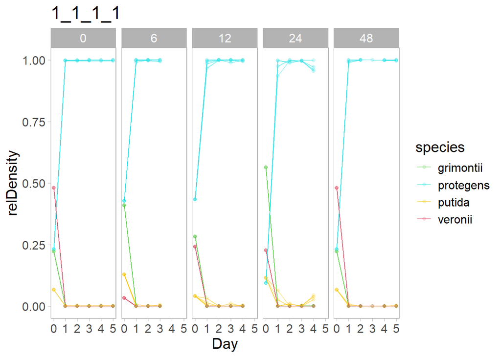

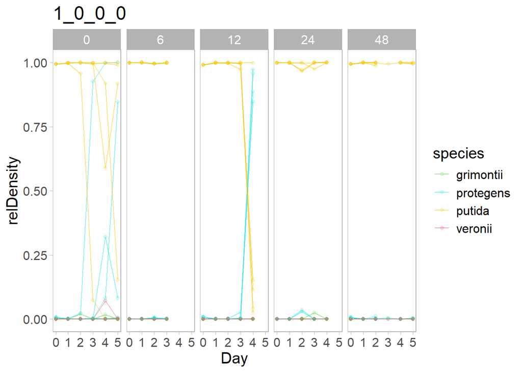

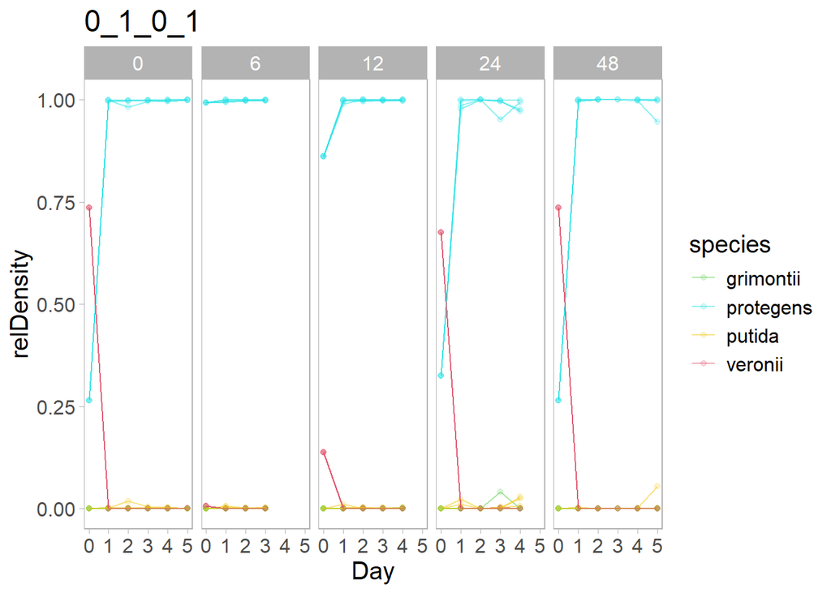

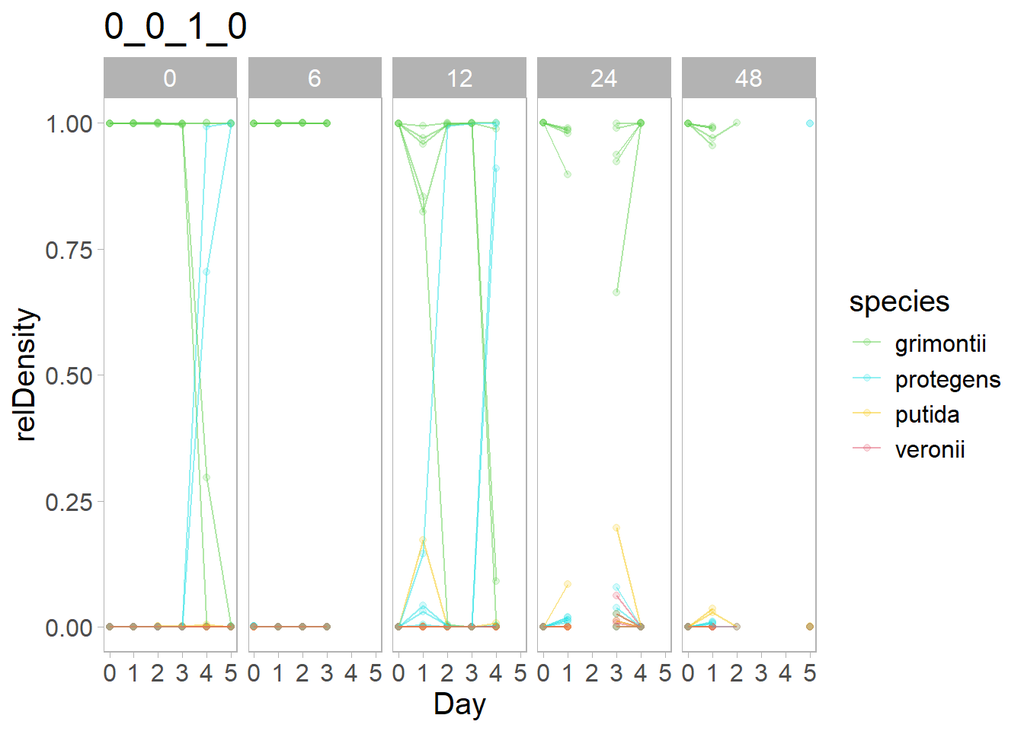

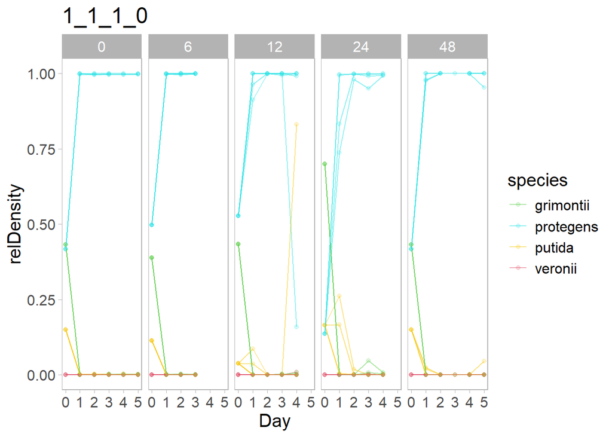

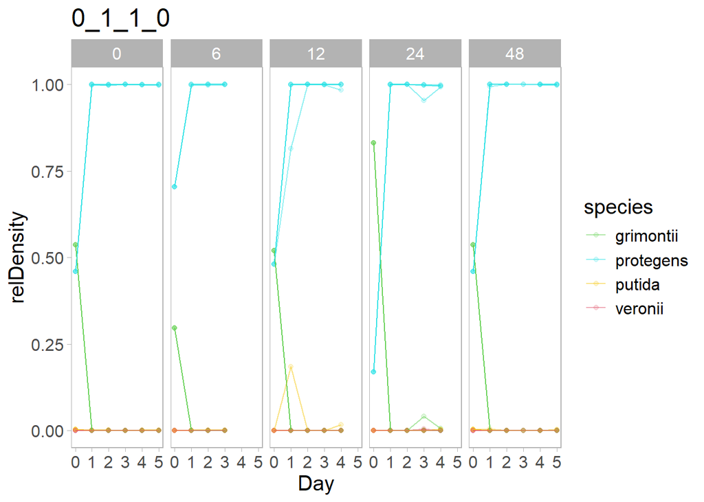

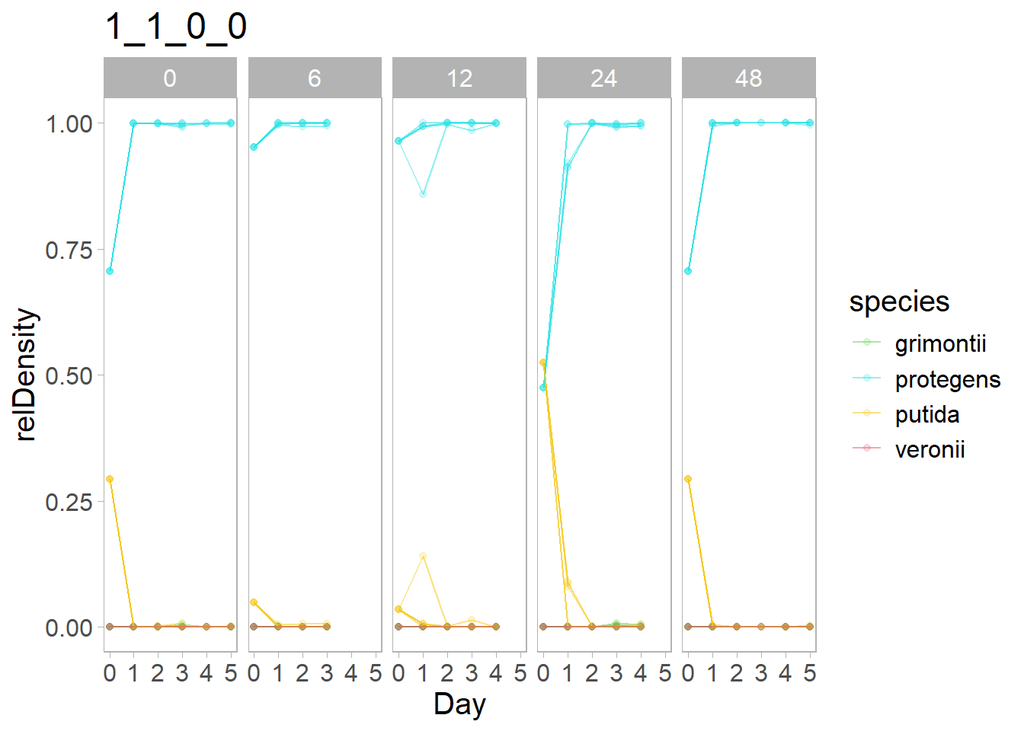

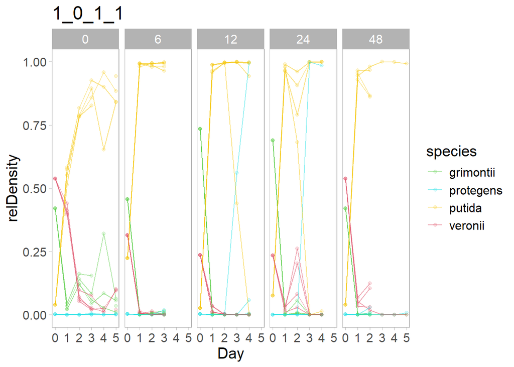

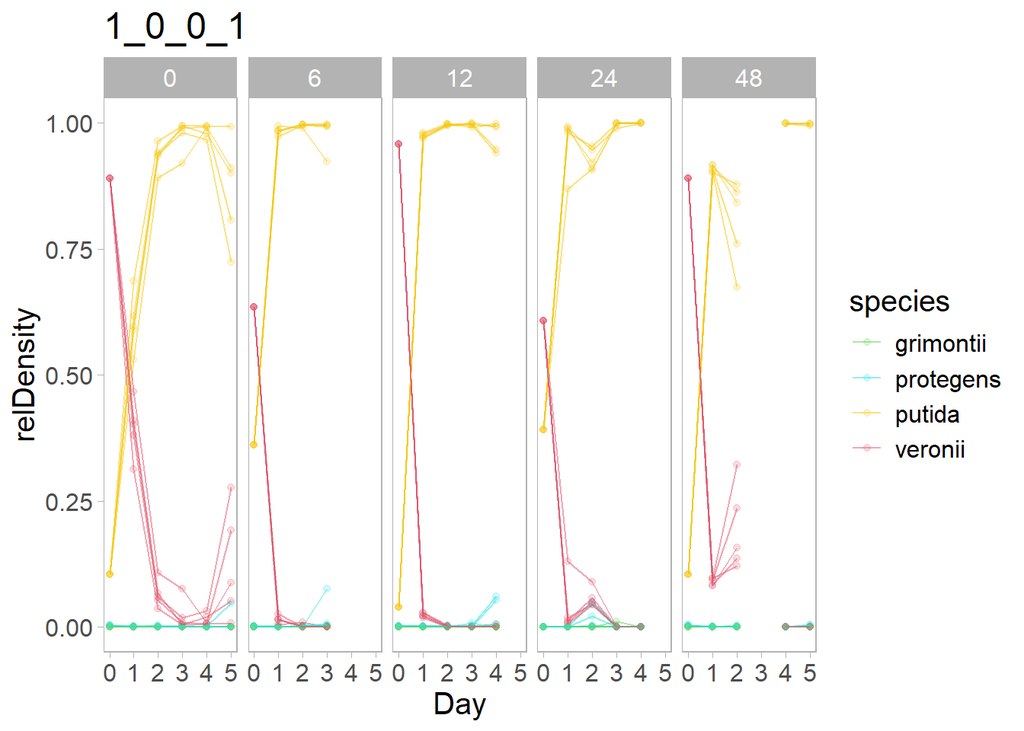

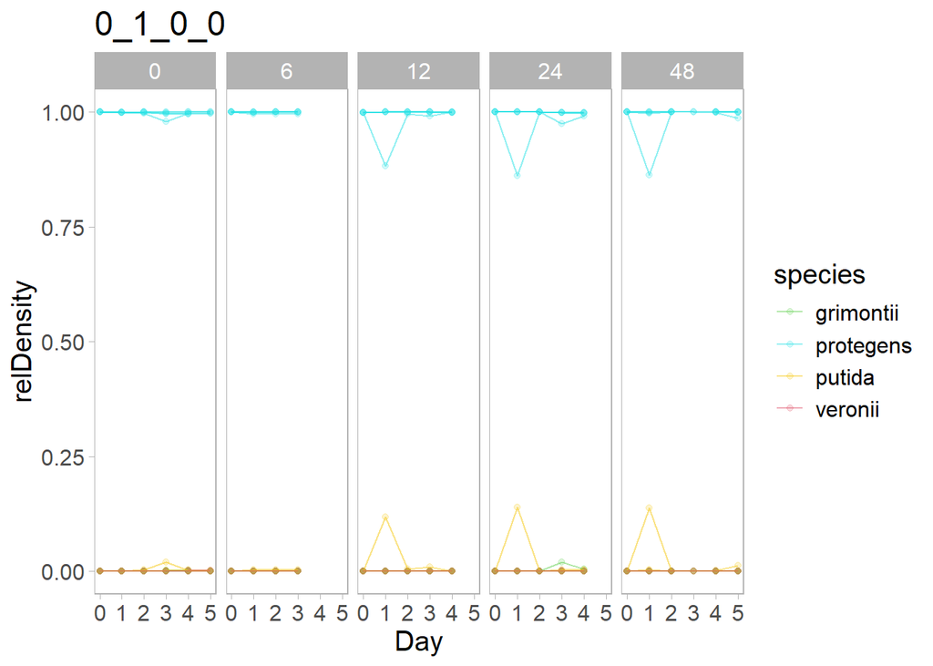

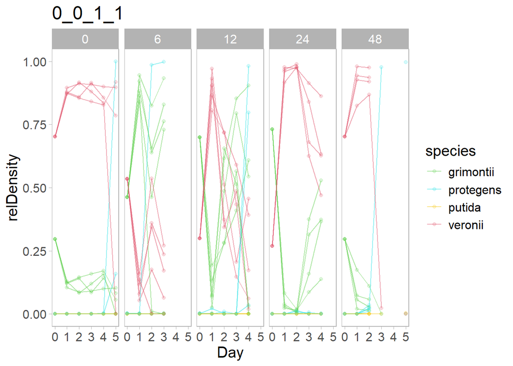

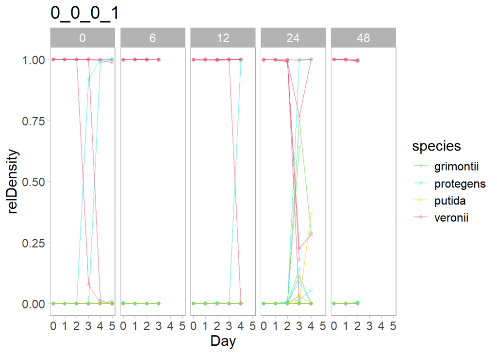

[4 more figures not shown]

```r
# check: is each replicated time series annotated appropriately so that it can be pieced together?
the.data <- the.data %>% unite("community", putida:veronii, remove=FALSE) %>% ungroup()
for(com in unique(the.data$community)) {
  plot( ggplot(the.data %>% filter(community==com) %>%
           select(uniqID, Heat, Day, relDen_putida, relDen_protegens, relDen_grimontii, relDen_veronii) %>%
              pivot_longer(cols=starts_with("relDen"), names_to="species", names_prefix="relDen_", values_to="relDensity"),
         aes(x=Day, y=relDensity, colour=species, group=paste(uniqID,Heat,species))) +
    facet_grid(~Heat) +
    geom_point(alpha=0.2) +
    geom_line(alpha=0.5) +
    scale_colour_manual(values=species_4pal_alphabetical) +
    labs(title=com))
}
```

```r
# clean up
rm(com)
```

## Identify wells driven to extinction

- Some occurred as a result of flow cytometry issues. E.G., there was probably a bubble that I didn’t notice. (When I noticed the bubble, I would re-run that well. But this is only after I began to understand that this was happening. So some wells were unfortunately lost because of this error.)  
  IN THIS CASE: this is a true NA value. It only happens at one time point (which may or may not be a heat day). And there is data for this well during the recovery period.
- Some occurred as a result of prolonged heat exposure that dropped the total density in that well below the threshold of detection. This only happened on day 3 of heat for the longest heat treatment. There is data for this well during the recovery period.  
  IN THIS CASE: this is a true NA value.
- Others occurred as a result of prolonged heat exposure that drove the well to complete extinction. There is no flow cytometery data for this well during the recovery period because it went extinct. Extinction needs to be confirmed against the OD data.  
  IN THIS CASE: this is a true NA value during the heat treatment **but it should become a 0 value during the recovery period.**

The OD data is analyzed in the file called `main_expt--OD_analysis.Rmd`. This script outputs a csv file indicating the extinct wells, which I will use below.

```r
# import extinct well data from file
extinct <- read.csv("./intermediate_data/extinctOD_wells.csv")

# we know that there was no detectable growth on Recovery days. So replace the current values with true 0's here.
the.data[which(the.data$uniqID %in% extinct$uniqID & the.data$Recov_Day>0),] <- the.data[which(the.data$uniqID %in% extinct$uniqID & the.data$Recov_Day>0),] %>%
          mutate(Total_density=0, Conc_putida=0, Conc_protegens=0, Conc_grimontii=0, Conc_veronii=0,
                 relDen_putida=0, relDen_protegens=0, relDen_grimontii=0, relDen_veronii=0,
                 CommRich=putida+protegens+grimontii+veronii)
# during the heat days, we know that there was no OD-detectable growth for (extinct$Day + 1).
# This means any flow cytometry data we have is unreliable and should be replaced with NA.
  # wells where Day 2 is unreliable
tmp <- extinct %>% filter(Day == 1)
the.data[which(the.data$uniqID %in% tmp$uniqID & the.data$Day==2),] <- the.data[which(the.data$uniqID %in% tmp$uniqID & the.data$Day==2),] %>%
          mutate(Total_density=NA, Conc_putida=NA, Conc_protegens=NA, Conc_grimontii=NA, Conc_veronii=NA,
                 relDen_putida=NA, relDen_protegens=NA, relDen_grimontii=NA, relDen_veronii=NA,
                 CommRich=NA)
rm(tmp)
  # wells where Day 3 is unreliable (and Day 3 is a heat day!)
extinct <- extinct[-which(extinct$uniqID %in% c("24-08-19 Epoch B4", "24-08-19 Epoch D2")),]
the.data[which(the.data$uniqID %in% extinct$uniqID & the.data$Day==3),] <- the.data[which(the.data$uniqID %in% extinct$uniqID & the.data$Day==3),] %>%
          mutate(Total_density=NA, Conc_putida=NA, Conc_protegens=NA, Conc_grimontii=NA, Conc_veronii=NA,
                 relDen_putida=NA, relDen_protegens=NA, relDen_grimontii=NA, relDen_veronii=NA,
                 CommRich=NA)
rm(extinct)
```

## Distinguish between contamination & misclassification

To address both the problem of contamination & the problem of the misclassification rate varying over time, I had to closely re-examine the flow cytometry raw data (which I did by eye, *insert crying emoji*).

From the Day 0 data, I hypothesized that the misclassification rate is ~1%. So let’s pull up the identity of all the flow cytometry data where >1% of the relative density is attributed to a species that was not inoculated in that well (i.e., and therefore it should not be there). I then manually examined the flow cytometry raw data files in FCS Express for all the wells listed below:

```r
# identify contamination at 1%
contamin.df <- the.data %>%  filter((putida == 0 & relDen_putida > 0.01) |
                                    (protegens == 0 & relDen_protegens > 0.01) |
                                    (grimontii == 0 & relDen_grimontii > 0.01) |
                                    (veronii == 0 & relDen_veronii > 0.01))

contamin.df %>% filter(Date %in% c("24-08-05", "24-08-19")) %>% select(Date, FLOWplateWell, Day, community,
                                                                       relDen_putida, relDen_protegens, relDen_grimontii, relDen_veronii)
```

| Date | FLOWplateWell | Day | community | relDen_putida | relDen_protegens | relDen_grimontii | relDen_veronii |
| --- | --- | --- | --- | --- | --- | --- | --- |
| 24-08-05 | plate1-F1 | 1 | 0_0_1_0 | 0.0000000000 | 0.1459107807 | 0.8540892193 | 0.0000000000 |
| 24-08-05 | plate1-B3 | 1 | 0_1_0_0 | 0.1181779115 | 0.8818220885 | 0.0000000000 | 0.0000000000 |
| 24-08-05 | plate1-C3 | 1 | 0_0_1_0 | 0.1719457014 | 0.0045248869 | 0.8235294118 | 0.0000000000 |
| 24-08-05 | plate1-A5 | 1 | 0_1_0_1 | 0.0109743931 | 0.9890256069 | 0.0000000000 | 0.0000000000 |
| 24-08-05 | plate1-F7 | 1 | 0_1_1_0 | 0.1854153719 | 0.8145846281 | 0.0000000000 | 0.0000000000 |
| 24-08-05 | plate1-H9 | 1 | 0_0_1_1 | 0.0000000000 | 0.0213592233 | 0.0747572816 | 0.9038834951 |
| 24-08-05 | plate1-F1 | 2 | 0_0_1_0 | 0.0001086602 | 0.9943496686 | 0.0055416712 | 0.0000000000 |
| 24-08-05 | plate1-F1 | 3 | 0_0_1_0 | 0.0003678725 | 0.9995095034 | 0.0001226242 | 0.0000000000 |
| 24-08-05 | plate1-F3 | 3 | 1_0_1_0 | 0.3145212429 | 0.6854787571 | 0.0000000000 | 0.0000000000 |
| 24-08-05 | plate1-E5 | 3 | 1_0_1_1 | 0.4393329500 | 0.5606670500 | 0.0000000000 | 0.0000000000 |

[output cut: 55 more lines]

The gating for all the wells listed above (and more) was double-checked by eye in FCS Express and new cell counts were outputted. It seemed to me that there is a correlation between the heat environment, or at least the day of the serial transfer, and how clean or messy the gating looked. In particular it seemed to me that it was more difficult to classify species during heat days.

We know from the OD data (see `main_expt--OD_analysis`) that the 24h of heat treatment had no instance of contamination detected (i.e., at least for the blank wells). Since I suspect that the misclassification rate changes with the heat day, let’s assume that the 24h heat treatment does not contain any contamination events then look at the occurence of species that were never inoculated in those wells as an estimate of the misclassification rate on different days of the serial transfer.

(In the future: it should also be possible to get a covariance matrix to estimate which species are being misclassified as which.)

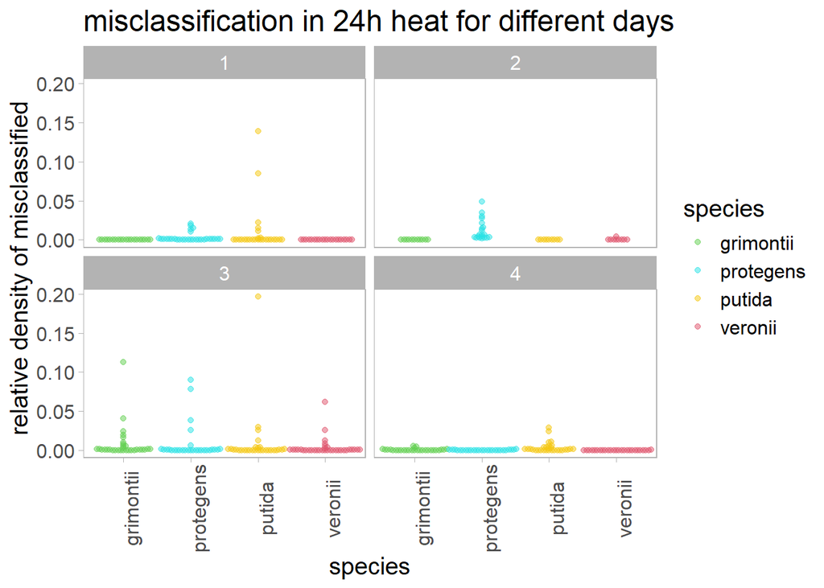

```r
misclass24 <- the.data %>% filter(Day > 0, Heat == 24) %>%
                filter((putida == 0 & relDen_putida > 0) |
                       (protegens == 0 & relDen_protegens > 0) |
                       (grimontii == 0 & relDen_grimontii > 0) |
                       (veronii == 0 & relDen_veronii > 0))
# separate the correctly called species from the species that are absent
misclass24_REAL <- misclass24 %>% mutate(relDen_putida = putida * relDen_putida,
                                         relDen_protegens = protegens * relDen_protegens,
                                         relDen_grimontii = grimontii * relDen_grimontii,
                                         relDen_veronii = veronii * relDen_veronii)
misclass24 <- misclass24 %>% mutate(relDen_putida = abs(putida-1) * relDen_putida,
                                    relDen_protegens = abs(protegens-1) * relDen_protegens,
                                    relDen_grimontii = abs(grimontii-1) * relDen_grimontii,
                                    relDen_veronii = abs(veronii-1) * relDen_veronii)
# pivot longer so there's a column for species
misclass24_REAL <- misclass24_REAL %>% pivot_longer(cols = relDen_putida:relDen_veronii,
                                                    values_to = "relDen",
                                                    names_to = "species",
                                                    names_prefix = "relDen_") %>%
                    select(uniqID, Day, community, putida, protegens, grimontii, veronii,
                           Total_density, relDen, species)
misclass24 <- misclass24 %>% pivot_longer(cols = relDen_putida:relDen_veronii,
                                                    values_to = "relDen",
                                                    names_to = "species",
                                                    names_prefix = "relDen_") %>%
                select(uniqID, Day, community, putida, protegens, grimontii, veronii,
                       Total_density, relDen, species)
# remove the true species from the misclass data because these are now fake 0's
misclass24 <- misclass24[-which(misclass24$putida == 1 & misclass24$species == "putida"),]
misclass24 <- misclass24[-which(misclass24$protegens == 1 & misclass24$species == "protegens"),]
misclass24 <- misclass24[-which(misclass24$grimontii == 1 & misclass24$species == "grimontii"),]
misclass24 <- misclass24[-which(misclass24$veronii == 1 & misclass24$species == "veronii"),]
# remove the single contaminated sample
misclass24 <- misclass24[-which(misclass24$protegens == 0 & misclass24$species == "protegens" & misclass24$relDen > 0.75),]

ggplot(misclass24,
       aes(x=species, y=relDen, colour=species)) +
  facet_wrap(vars(Day)) +
  geom_beeswarm(alpha=0.5) +
  scale_colour_manual(values=species_4pal_alphabetical) +
  theme(axis.text.x = element_text(angle = 90)) +
  labs(y="relative density of misclassified",
       title="misclassification in 24h heat for different days")
```

```r
# clean up
rm(misclass24, misclass24_REAL)
```

Recall that for 24h duration, Day 1 of serial transfer had 6h of extreme heat at the end, Day 2 was all extreme heat then returned to the “ambient” warm temperature only in the last few hours, and Days 3 & 4 were the recovery days with constant “ambient” warm temperature.

What we see from the plot above is that the misclassification rate can get as high as 20% (and that it does depend on the day but it seems that the first day of recovery is actually worse than the heat days themselves), although most replicates & days seem to be well behaved.

Therefore let’s set 25% as the threshold for contamination. This means that any replicates that show >25% relative density for a species that was not inoculated there are defined as contaminated. All time-points from these contaminated replicates are completely removed from the downstream analysis.

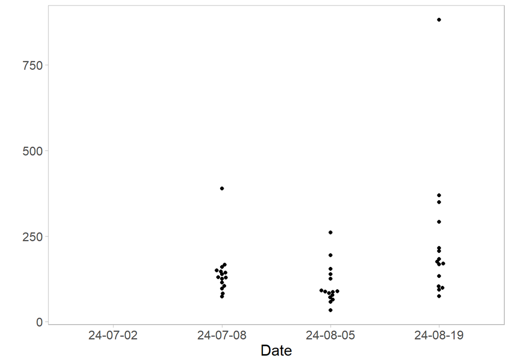

```r
rm(contamin.df) # remove anything we may have had above.

# for now let's define contamination as >25% for something that should not be there.
contamin.df <- the.data %>%  filter((putida == 0 & relDen_putida > 0.25) |
                                    (protegens == 0 & relDen_protegens > 0.25) |
                                    (grimontii == 0 & relDen_grimontii > 0.25) |
                                    (veronii == 0 & relDen_veronii > 0.25))
tmp <- the.data[-which(the.data$uniqID %in% unique(contamin.df$uniqID)),]

###############
# output absolute density data for analysis
###############

# Day 0 would need to be the pre-dilution absolute densities
ggplot(tmp %>% filter(Day==0) %>% select(-uniqID, -OD_well, -Heat, -Incubator) %>% distinct(),
       aes(x=Date, y=Total_density)) +
  geom_beeswarm() +
  labs(y="")
```

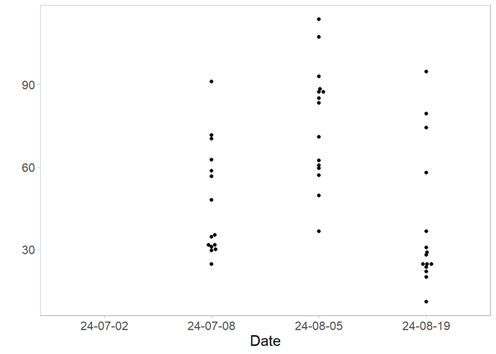

```r
ggplot(tmp %>% filter(Day==0) %>% select(-uniqID, -OD_well, -Heat, -Incubator) %>% distinct(),
       aes(x=Date, y=Volume)) +
  geom_beeswarm() +
  labs(y="")
```

```r
# I lost the data on flow volume for Date 24-07-02.
# But we see from the plot that there's not *that* much variation between batches.

## IMPORTANT NOTE: the Day 0 data is not featured in any of the downstream analyses for this manuscript. Therefore this interpolation doesn't actually matter.

# let's interpolate the well volumes on Day 0 of 24-07-02 by using the median well volumes for all other dates on Day 0
tmp.Day0 <- tmp[which(tmp$Day==0 & tmp$Incubator=="Epoch"),] %>% select(-uniqID, -OD_well) %>% distinct()
  # get the median volume for Day 0
medianVol <- median(tmp.Day0$Volume, na.rm=TRUE)
  # apply the median volume to Day 0 values from 24-07-02
tmp.Day0 <- tmp.Day0 %>% filter(Date=="24-07-02")
tmp.Day0$Volume <- medianVol
  # recalculate the absolute densities for Day0
tmp.Day0 <- tmp.Day0 %>% mutate(Total_density = Total_counts/Volume,
                                Conc_putida = Count_putida/Volume,
                                Conc_protegens = Count_protegens/Volume,
                                Conc_grimontii = Count_grimontii/Volume,
                                Conc_veronii = Count_veronii/Volume)
# finally, join the estimated absolute densities for Day0 back in with the whole data
tmp.Day0.0702 <- left_join(tmp %>% filter(Day==0, Date=="24-07-02") %>% select(-Volume, -Total_density, -Conc_putida, -Conc_protegens, -Conc_grimontii, -Conc_veronii),
                           tmp.Day0)
```

[output not shown]

```r
tmp <- rbind(tmp %>% filter(Date != "24-07-02"),
             tmp %>% filter(Date == "24-07-02") %>% filter(Day > 0),
             tmp.Day0.0702)

rm(medianVol, tmp.Day0, tmp.Day0.0702)

# finally, remove known miscalled estimates from the data
tmp <- tmp %>% mutate(Conc_putida = putida * Conc_putida,
                      Conc_protegens = protegens * Conc_protegens,
                      Conc_grimontii = grimontii * Conc_grimontii,
                      Conc_veronii = veronii * Conc_veronii) %>%
        mutate(Total_density = Conc_putida + Conc_protegens + Conc_grimontii + Conc_veronii)

# output this data to file
absDensity <- tmp %>% filter(community != "0_0_0_0") %>%
                select(uniqID, Heat, Day, Heat_Day, Recov_Day, CommRich:veronii, Total_density:Conc_veronii)
save(absDensity, file="./intermediate_data/absolute_density_data.RData")

rm(tmp, com, contamin.df)
```

## Plot final time-series

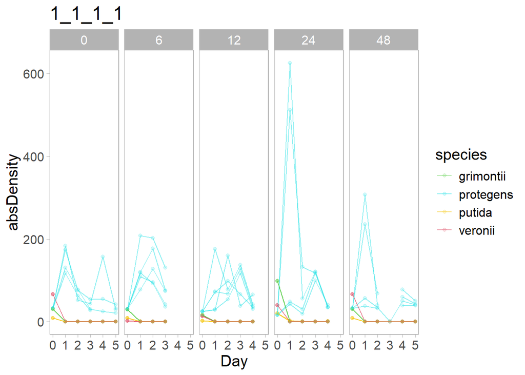

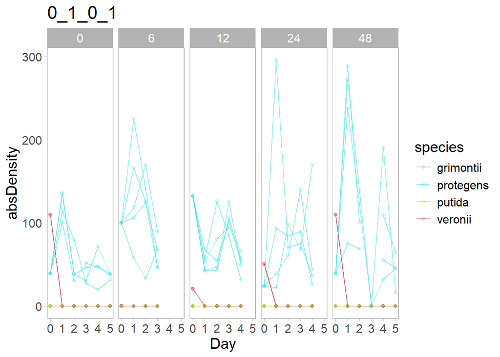

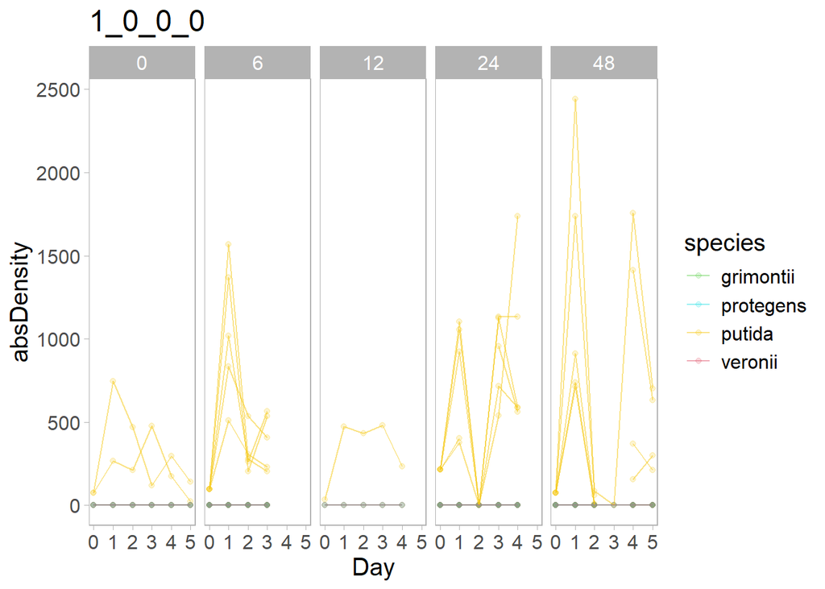

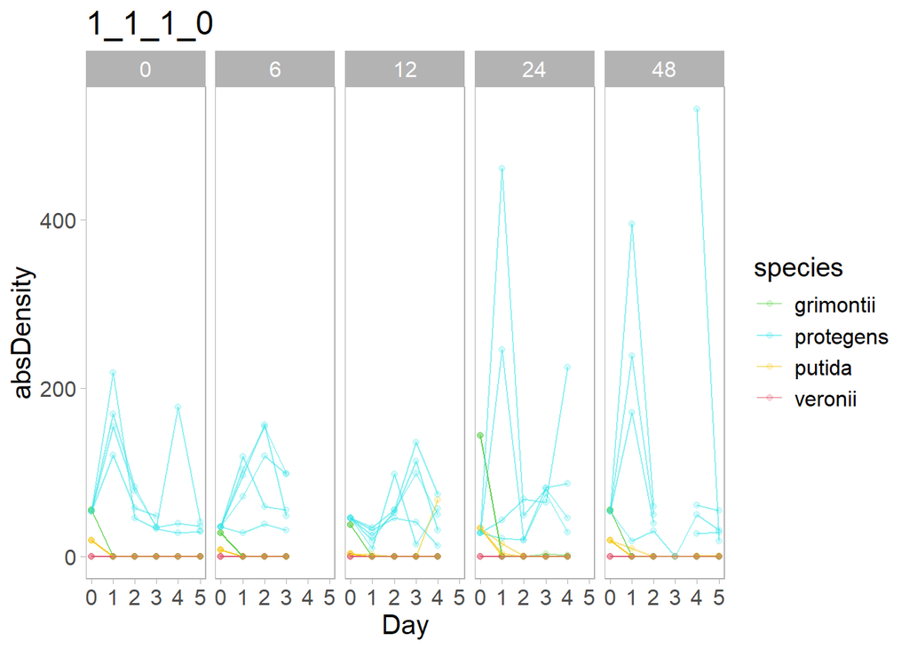

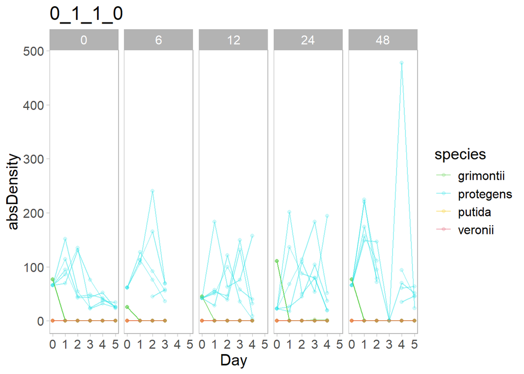

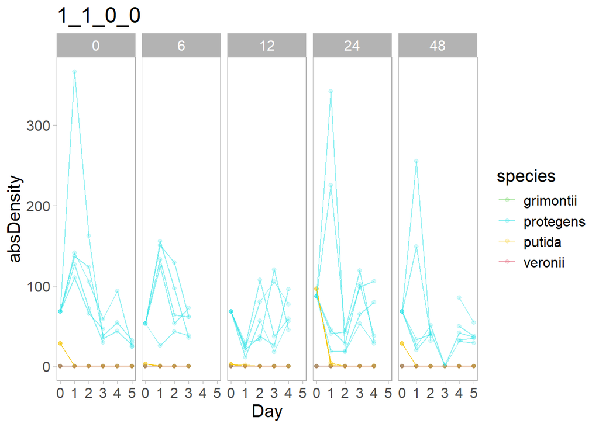

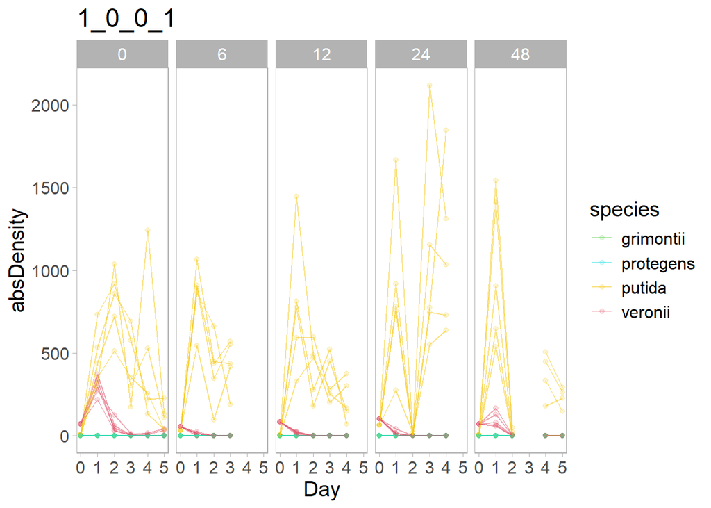

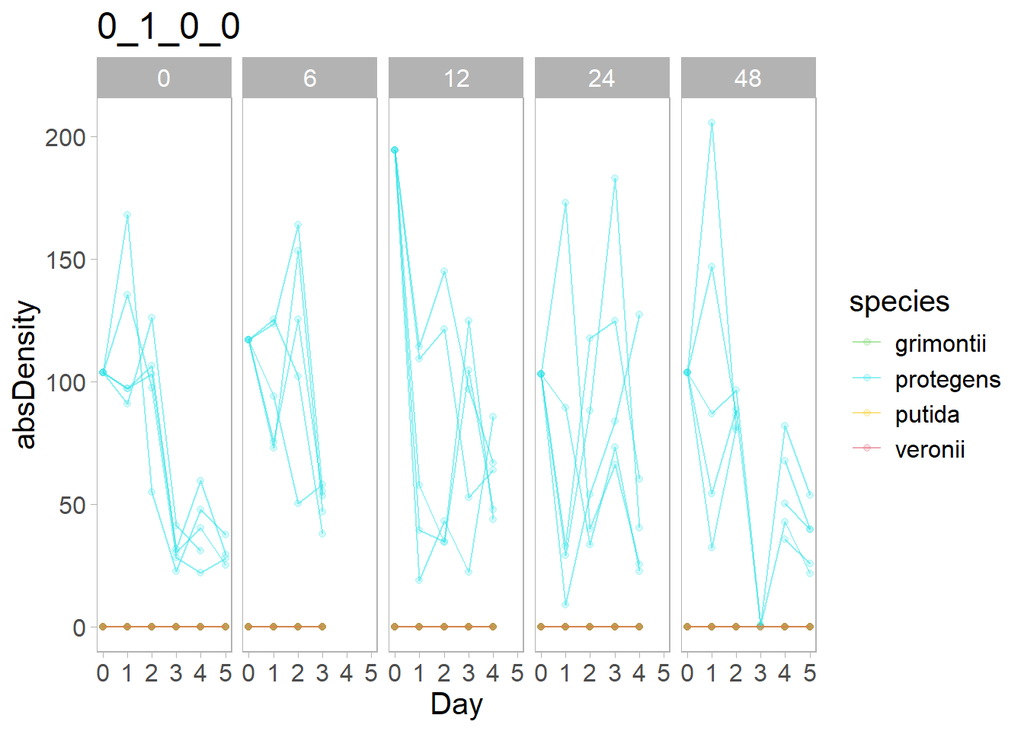

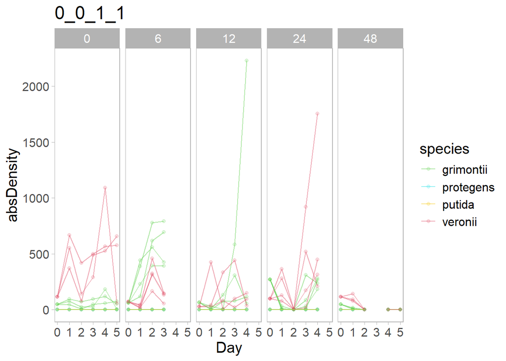

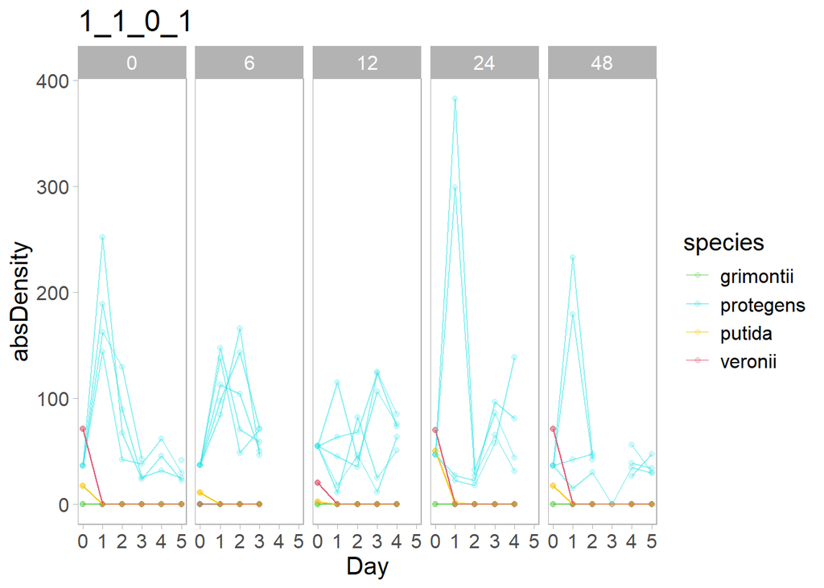

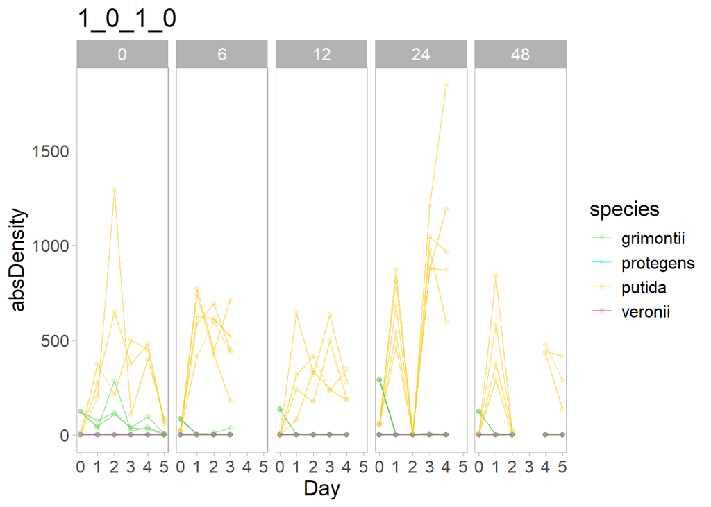

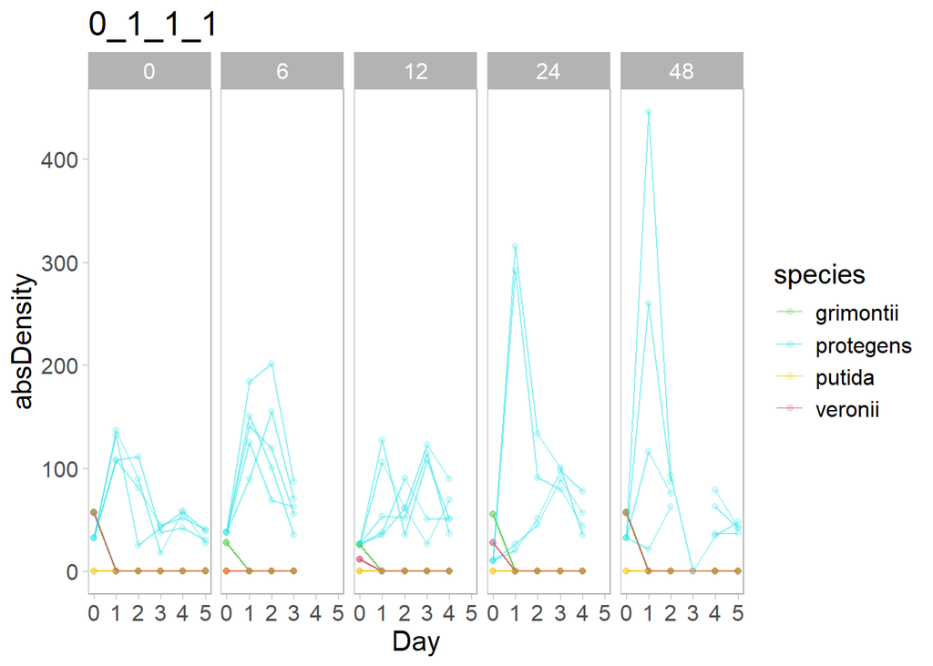

[3 more figures not shown]

```r
for(com in unique(absDensity$community)) {
  plot(ggplot(absDensity %>% filter(community==com) %>%
           select(uniqID, Heat, Day, Conc_putida, Conc_protegens, Conc_grimontii, Conc_veronii) %>%
              pivot_longer(cols=starts_with("Conc"), names_to="species", names_prefix="Conc_", values_to="absDensity"),
         aes(x=Day, y=absDensity, colour=species, group=paste(uniqID,Heat,species))) +
    facet_grid(~Heat) +
    geom_point(alpha=0.2) +
    geom_line(alpha=0.5) +
    scale_colour_manual(values=species_4pal_alphabetical) +
    labs(title=com))
}
```

```r
# in the analyses below we will be interested in shannon diversity so let's already make a column for that
absDensity$Diversity <- diversity(absDensity[,c("Conc_putida", "Conc_protegens", "Conc_grimontii", "Conc_veronii")],
                                  index = "shannon")

# first let's remove the empty wells as we won't need them anymore
absDensity <- absDensity %>% filter(community != "0_0_0_0")
# Note that there are many 0 and NA values for Total_density
summary(absDensity$Total_density)
```

```
##    Min. 1st Qu.  Median    Mean 3rd Qu.    Max.    NA's
##    0.00   47.03  100.25  219.98  220.90 2674.00      72
```

```r
# 0's are communities that went extinct altogether and never recovered
absDensity[which(absDensity$Total_density == 0),]
```

| uniqID | Heat | Day | Heat_Day | Recov_Day | CommRich | community | putida | protegens | grimontii | veronii | Total_density | Conc_putida | Conc_protegens | Conc_grimontii | Conc_veronii | Diversity |
| --- | --- | --- | --- | --- | --- | --- | --- | --- | --- | --- | --- | --- | --- | --- | --- | --- |
| 24-07-08 H1 E1 | 48 | 4 | NA | 1 | 1 | 0_0_0_1 | 0 | 0 | 0 | 1 | 0 | 0 | 0 | 0 | 0 | 0 |
| 24-07-08 H1 F1 | 48 | 4 | NA | 1 | 1 | 0_0_1_0 | 0 | 0 | 1 | 0 | 0 | 0 | 0 | 0 | 0 | 0 |
| 24-07-08 H1 D2 | 48 | 4 | NA | 1 | 1 | 0_0_0_1 | 0 | 0 | 0 | 1 | 0 | 0 | 0 | 0 | 0 | 0 |
| 24-07-08 H1 E3 | 48 | 4 | NA | 1 | 3 | 1_0_1_1 | 1 | 0 | 1 | 1 | 0 | 0 | 0 | 0 | 0 | 0 |
| 24-07-08 H1 C4 | 48 | 4 | NA | 1 | 1 | 0_0_1_0 | 0 | 0 | 1 | 0 | 0 | 0 | 0 | 0 | 0 | 0 |
| 24-07-08 H1 D4 | 48 | 4 | NA | 1 | 1 | 0_0_0_1 | 0 | 0 | 0 | 1 | 0 | 0 | 0 | 0 | 0 | 0 |
| 24-07-08 H1 F4 | 48 | 4 | NA | 1 | 2 | 1_0_1_0 | 1 | 0 | 1 | 0 | 0 | 0 | 0 | 0 | 0 | 0 |
| 24-07-08 H1 G4 | 48 | 4 | NA | 1 | 2 | 1_0_0_1 | 1 | 0 | 0 | 1 | 0 | 0 | 0 | 0 | 0 | 0 |
| 24-07-08 H1 C5 | 48 | 4 | NA | 1 | 3 | 1_0_1_1 | 1 | 0 | 1 | 1 | 0 | 0 | 0 | 0 | 0 | 0 |
| 24-07-08 H1 H5 | 48 | 4 | NA | 1 | 2 | 0_0_1_1 | 0 | 0 | 1 | 1 | 0 | 0 | 0 | 0 | 0 | 0 |

[output cut: 28 more lines]

```r
# most NA's are communities below the threshold of detection during heat that later perhaps recovered
absDensity[which(is.na(absDensity$Total_density) & absDensity$Heat>12),]
```

| uniqID | Heat | Day | Heat_Day | Recov_Day | CommRich | community | putida | protegens | grimontii | veronii | Total_density | Conc_putida | Conc_protegens | Conc_grimontii | Conc_veronii | Diversity |
| --- | --- | --- | --- | --- | --- | --- | --- | --- | --- | --- | --- | --- | --- | --- | --- | --- |
| 24-07-08 H1 F1 | 48 | 2 | 2 | NA | NA | 0_0_1_0 | 0 | 0 | 1 | 0 | NA | NA | NA | NA | NA | NA |
| 24-07-08 H1 D2 | 48 | 2 | 2 | NA | NA | 0_0_0_1 | 0 | 0 | 0 | 1 | NA | NA | NA | NA | NA | NA |
| 24-07-08 H1 C4 | 48 | 2 | 2 | NA | NA | 0_0_1_0 | 0 | 0 | 1 | 0 | NA | NA | NA | NA | NA | NA |
| 24-07-08 H1 D4 | 48 | 2 | 2 | NA | NA | 0_0_0_1 | 0 | 0 | 0 | 1 | NA | NA | NA | NA | NA | NA |
| 24-07-08 H1 B1 | 48 | 3 | 3 | NA | NA | 1_0_0_1 | 1 | 0 | 0 | 1 | NA | NA | NA | NA | NA | NA |
| 24-07-08 H1 C1 | 48 | 3 | 3 | NA | NA | 1_0_1_0 | 1 | 0 | 1 | 0 | NA | NA | NA | NA | NA | NA |
| 24-07-08 H1 E1 | 48 | 3 | 3 | NA | NA | 0_0_0_1 | 0 | 0 | 0 | 1 | NA | NA | NA | NA | NA | NA |
| 24-07-08 H1 F1 | 48 | 3 | 3 | NA | NA | 0_0_1_0 | 0 | 0 | 1 | 0 | NA | NA | NA | NA | NA | NA |
| 24-07-08 H1 D2 | 48 | 3 | 3 | NA | NA | 0_0_0_1 | 0 | 0 | 0 | 1 | NA | NA | NA | NA | NA | NA |
| 24-07-08 H1 G2 | 48 | 3 | 3 | NA | NA | 1_0_0_1 | 1 | 0 | 0 | 1 | NA | NA | NA | NA | NA | NA |

[output cut: 53 more lines]

```r
# other NA's are just missing data (e.g., due to flow cytometry clogs or just plain pipetting mistakes)
absDensity[which(is.na(absDensity$Total_density) & absDensity$Heat<12),]
```

| uniqID | Heat | Day | Heat_Day | Recov_Day | CommRich | community | putida | protegens | grimontii | veronii | Total_density | Conc_putida | Conc_protegens | Conc_grimontii | Conc_veronii | Diversity |
| --- | --- | --- | --- | --- | --- | --- | --- | --- | --- | --- | --- | --- | --- | --- | --- | --- |
| 24-07-08 Epoch E2 | 0 | 4 | NA | NA | NA | 1_1_0_0 | 1 | 1 | 0 | 0 | NA | NA | NA | NA | NA | NA |
| 24-07-08 Epoch E3 | 0 | 4 | NA | NA | NA | 1_0_1_1 | 1 | 0 | 1 | 1 | NA | NA | NA | NA | NA | NA |
| 24-07-08 Epoch E4 | 0 | 4 | NA | NA | NA | 1_1_0_0 | 1 | 1 | 0 | 0 | NA | NA | NA | NA | NA | NA |
| 24-07-08 Epoch E5 | 0 | 4 | NA | NA | NA | 1_1_1_1 | 1 | 1 | 1 | 1 | NA | NA | NA | NA | NA | NA |
| 24-07-08 Epoch G1 | 0 | 5 | NA | NA | 1 | 0_1_0_0 | 0 | 1 | 0 | 0 | NA | NA | NA | NA | NA | NA |
| 24-07-08 Epoch E9 | 0 | 4 | NA | NA | NA | 0_0_1_0 | 0 | 0 | 1 | 0 | NA | NA | NA | NA | NA | NA |
| 24-07-08 Epoch E10 | 0 | 4 | NA | NA | NA | 1_1_1_0 | 1 | 1 | 1 | 0 | NA | NA | NA | NA | NA | NA |
| 24-07-08 Epoch E12 | 0 | 4 | NA | NA | NA | 1_1_0_1 | 1 | 1 | 0 | 1 | NA | NA | NA | NA | NA | NA |
| 24-07-02 Epoch A6 | 6 | 1 | 1 | NA | 2 | 0_1_1_0 | 0 | 1 | 1 | 0 | NA | NA | NA | NA | NA | NA |

```r
# the total density data will have to be slightly adjusted for fitting to the models
absDen_forFit <- absDensity %>% filter(Day > 0)
# for the "raw" total density data that will be fitted via negative binomial GLM,
  # keep the 0's in the data
  # but convert NA's into epsilon values (where epsilon is just below the threshold of detection)
below_threshold_rows <- which(is.na(absDen_forFit$Total_density) & absDen_forFit$Heat>12)
absDen_forFit$Total_density[below_threshold_rows] <- (0.25*50/146)
rm(below_threshold_rows)

# re-arrange the levels of Heat so that emmeans can be run:
absDen_forFit$Heat <- as.character(absDen_forFit$Heat)
absDen_forFit$Heat[which(absDen_forFit$Heat == 0)] <- "control"
# !!! emmeans expects the control to be the very *last* level !!!
absDen_forFit$Heat <- factor(absDen_forFit$Heat,
                             levels = c("6", "12", "24", "48", "control"))

# clean up
rm(com)
```

Below, I will analyze the diversity and the productivity (AKA total density) to understand how they change relative to the no heat control during the resistance and the recovery period. The diversity is easier to deal with because we can use the Shannon diversity calculation as implemented by `vegan`.

For the total abundances, there are extinction (AKA 0’s) and NA events in this data – the extinction events in particular are important and meaningful parts of our data!! To deal with this issue, I will distinguish between 0’s and NA’s by using a $x + \epsilon$ transformation, where $\epsilon$ indicates samples that are below the threshold of detection. I will use $\epsilon$ as 0.25 * the threshold of detection for the flow cytometer (which is 50 total fluorescent events in $146\mu L$).

## Load community growth traits expectations

We define “average growth rate of the community” either as the expectation from the inoculated communities (e.g., the quadruplet community has expected growth rate = mean of the 4 species). In other words, this assumes that all species that were inoculated in the community remain at equal ratios and therefore the average growth rate of a community is just the mean of the growth rates of the species that were inoculated there. This is called the `community_expected_mu`. (Recall that if we thought the communities would stay fixed for the equal species ratios that we inoculated them at, then we should use the geometric mean to calculate the community growth rate. We use the arithmetic mean because we *a priori* believe that the communities will tend to be dominated by the faster growing species.)

We also define it as the mean of the realized communities by using the species mean relative densities in the no heat control condition. In other words, this takes into account the actual relative densities of the species that can hang out together across serial transfers and uses that as an expectation of the community’s growth rate. This is called the `community_averaged_mu`.

Another trait that we assayed was whether species are sensitive or resistant to 40C heat (resistance is a binary trait: either TRUE or FALSE). We define communities as expected to be resistant when at least one of the inoculated species is resistant. We define communities as expected to be sensitive when none of the species are resistant.

```r
# load in the stationary phase growth rate estimates from Expt1
load("./intermediate_data/expt1--all_growthcurve_data.RData")
rm(ALL_data.df, derivs.df, TTD.df) # keep just the dataframe with the growth rate estimates (mu)

# a look-up table for growth rates at 30C
growthrates.df <- Dil_growthrates.df %>% filter(Inoculum == "Stationary",
                                                Temp == 30,
                                                Sample %in% c("BSC001", "BSC005", "BSC019", "CK101")) %>%
                        arrange(desc(mu))

# a look-up table for resistance to 40C
resist.df <- Dil_growthrates.df %>% filter(Inoculum == "Stationary",
                                           Temp == 40,
                                           Sample %in% c("BSC001", "BSC005", "BSC019", "CK101")) %>%
                mutate(resistant = ifelse(mu>0, 1, 0)) %>%
                  arrange(match(Sample, c("BSC001", "CK101", "BSC019", "BSC005")))

# calculate the average growth rate for the inoculated communities
absDen_forFit <- absDen_forFit %>% mutate(community_expected_mu = (growthrates.df$mu[1]*putida + growthrates.df$mu[2]*protegens + growthrates.df$mu[3]*grimontii + growthrates.df$mu[4]*veronii)/(putida + protegens + grimontii + veronii))

# calculate the average growth rate for the realized communities
temp <- absDensity %>% filter(Heat == 0) %>% group_by(community) %>%
          mutate(relDen_putida = Conc_putida/Total_density,
                 relDen_protegens = Conc_protegens/Total_density,
                 relDen_grimontii = Conc_grimontii/Total_density,
                 relDen_veronii = Conc_veronii/Total_density) %>%
            summarise(relDen_putida = median(relDen_putida, na.rm = TRUE),
                      relDen_protegens = median(relDen_protegens, na.rm = TRUE),
                      relDen_grimontii = median(relDen_grimontii, na.rm = TRUE),
                      relDen_veronii = median(relDen_veronii, na.rm = TRUE)) %>%
              mutate(community_averaged_mu = growthrates.df$mu[1]*relDen_putida + growthrates.df$mu[2]*relDen_protegens + growthrates.df$mu[3]*relDen_grimontii + growthrates.df$mu[4]*relDen_veronii)

# get the community resistances
print(resist.df %>% select(Species, Sample, Temp, mu, resistant)) # recall that only putida is resistant
```

```
##        Species Sample Temp      mu resistant
## 1    P. putida BSC001   40 0.40721         1
## 2 P. protegens  CK101   40 0.00000         0
## 3 P. grimontii BSC019   40 0.00000         0
## 4   P. veronii BSC005   40 0.00000         0
```

```r
# so it's easy to get community resistance because it's just the presence/absence of putida

# add the information to the full data set
absDen_forFit <- inner_join(absDen_forFit, temp %>% select(community, community_averaged_mu)) %>%
                  mutate(resistant = putida)
```

```r
# remember to also add the community growth rates and resistances to the other data frame (this one is used for the extinction analysis because Heat is numeric here)
absDensity <- inner_join(absDensity,
                         absDen_forFit %>%
                           select(community, community_expected_mu, community_averaged_mu, resistant) %>%
                             distinct())
# clean up
rm(temp, Dil_growthrates.df, resist.df, growthrates.df)
```

# Ordination of communities over time

After backing up a bit and thinking about what the main story of the paper could be, I think the main message that I would like to tell with the paper is that heat duration has a threshold effect. So while shorter and intermediate heat durations have some effect during heat that is different from control, communities return to a similar state after recovery. On the other hand, long duration heat events lead to extinction (i.e., either of the entire community or of vulnerable species within the community) so the communities cannot recover anymore. In other words, there’s a threshold effect where the amount of heat (or bacterial) induced killing has gone on for so long than it passes a critical point and the communities recover to a different state. I don’t want to use the term “tipping point” but for sure the design of our experiment allows us to use phrases like “threshold effect” and “critical transition” *sensu stricto* (e.g., as explained in [Munson et al., 2018](https://doi.org/10.1111/nph.15145)).

I think it would be fantastic if I could produce a figure that summarizes the entire data in a way that builds an argument for the quintessential ball-landscape schematic that people keep showing when they talk about ecosystem stability to perturbation (e.g., see schematic in Fig. 2 of [Shade et al., 2012](https://doi.org/10.3389/fmicb.2012.00417) or the empirical figure in Fig. 3 of [Jurburg et al., 2017](https://doi.org/10.1038/srep45691)).

Here are some tutorials on ordination: https://eddatascienceees.github.io/tutorial-rayrr13/ https://ourcodingclub.github.io/tutorials/ordination/ https://uw.pressbooks.pub/appliedmultivariatestatistics/chapter/anosim/ https://uw.pressbooks.pub/appliedmultivariatestatistics/chapter/visualizing-and-interpreting-ordinations/

To calculate the Bray-Curtis dissimilarity, we are forced to choose how to deal with NA values (most of which are found in the resistance time points and so it doesn’t really make sense to outright drop them). NA values exist for two reasons:

1. “true” missing data where the well was not acquired at all due to technical difficulties/mistakes (only a few of this type). I used interpolation to deal with these: use the median value from other replicates at that same community:day:treatment.
2. below threshold of detection missing data where the total density was too low to reliably estimate the cell counts. I replace the NA with the limit of detection of the cytometer (epsilon = 0.25*50/146, as above) and assume equal frequencies of the species that were inoculated in that community.

Then, if we just follow the example tutorials directly, with columns = four species and rows = different communities on different days for different heat treatments, then the data simply gets split up by species. But that’s not what we want to understand in this case.

We want to understand how the communities are changing over time (and as a function of different heat durations) so let’s give it the data as species x time. This can be achieved by widening the data so that we have abundances of the 4 species during resistance, during early recovery, and during late recovery.

Note that I also had to keep just 3 time points from the control treatment. I chose to keep day 1 (coded as “resistance”), day 3 (coded as “early recovery”), and day 5 (coded as “late recovery”) because this way the ordination plot will show the control treatment early, middle, and late in the time series…

```r
# go back to the complete data that includes NA values for all 4 species on some days
absDen_forOrd <- absDen_forFit %>% select(-Diversity, -community_expected_mu, -community_averaged_mu, -resistant)
# NA values with Total_density == NA are "true" missing data where I failed to record the flow cytometry measurements on that day due to technical difficulties/mistakes. These can be interpolated by using the median values from the remaining community replicates
  ## get the median values for all communities, days, and heat treatments
median_vals <- absDen_forOrd %>% group_by(Heat, Day, community) %>%
                  summarise(Med_putida = median(Conc_putida, na.rm=TRUE),
                            Med_protegens = median(Conc_protegens, na.rm=TRUE),
                            Med_grimontii = median(Conc_grimontii, na.rm=TRUE),
                            Med_veronii = median(Conc_veronii, na.rm=TRUE))
  ## get the index for the rows with "true" missing values
missing_rows <- which(is.na(absDen_forOrd$Total_density))
  ## loop through the missing values
for(i in missing_rows){
  # find the interpolation value in the table of median values
  temp_med_val <- median_vals[median_vals$Heat == absDen_forOrd$Heat[i] &
                                median_vals$Day == absDen_forOrd$Day[i] &
                                median_vals$community == absDen_forOrd$community[i],]
  # replace the NA values with the median values
  absDen_forOrd$Conc_putida[i] <- temp_med_val$Med_putida
  absDen_forOrd$Conc_protegens[i] <- temp_med_val$Med_protegens
  absDen_forOrd$Conc_grimontii[i] <- temp_med_val$Med_grimontii
  absDen_forOrd$Conc_veronii[i] <- temp_med_val$Med_veronii
  # clean up
  rm(temp_med_val)
}
# clean up
rm(median_vals, missing_rows, i)

# on the other hand, NA values where Total_density is epsilon represent flow cytometry counts that were below the threshold of detection. In this case let's assume 1:1 ratios of inoculated strains at a total density equal to epsilon.
epsilon <- (0.25*50/146)
  ## get the index for the missing value rows below the threshold of detection
missing_rows <- which(is.na(absDen_forOrd$Conc_putida))
  ## CommRich NA values were supposed to indicate some differences but that doesn't really matter for us anymore
absDen_forOrd$CommRich <- absDen_forOrd$putida + absDen_forOrd$protegens + absDen_forOrd$grimontii + absDen_forOrd$veronii
for(i in missing_rows){
  # replace the NA values with epsilon divided by the inoculated species richness
  absDen_forOrd$Conc_putida[i] <- absDen_forOrd$putida[i] * epsilon / absDen_forOrd$CommRich[i]
  absDen_forOrd$Conc_protegens[i] <- absDen_forOrd$protegens[i] * epsilon / absDen_forOrd$CommRich[i]
  absDen_forOrd$Conc_grimontii[i] <- absDen_forOrd$grimontii[i] * epsilon / absDen_forOrd$CommRich[i]
  absDen_forOrd$Conc_veronii[i] <- absDen_forOrd$veronii[i] * epsilon / absDen_forOrd$CommRich[i]
}
# re-order the levels of Heat for better plotting
absDen_forOrd$Heat <- factor(absDen_forOrd$Heat, levels=c("control", "6", "12", "24", "48"))
# finally, we can drop the total density column
absDen_forOrd <- absDen_forOrd %>% select(-Total_density)
rm(epsilon, missing_rows, i)

# first we have to widen the data:
# create a column that indicates the treatment day as resistance, early recovery, or late recovery
absDen_forOrd$trtmt_day <- "resist"
absDen_forOrd$trtmt_day[absDen_forOrd$Recov_Day == 1] <- "early_recov"
absDen_forOrd$trtmt_day[absDen_forOrd$Recov_Day == 2] <- "late_recov"
# ENTIRELY ARBITARARILY: I will keep days 1, 3, and 5 for control
absDen_forOrd$trtmt_day[absDen_forOrd$Heat == "control" & absDen_forOrd$Day == 3] <- "early_recov"
absDen_forOrd$trtmt_day[absDen_forOrd$Heat == "control" & absDen_forOrd$Day == 5] <- "late_recov"
# remove day 1 for 12h, 24h, 48h AND day 2 for 48h.
absDen_forOrd <- absDen_forOrd[!(absDen_forOrd$Heat == 12 & absDen_forOrd$Day == 1), ]
absDen_forOrd <- absDen_forOrd[!(absDen_forOrd$Heat == 24 & absDen_forOrd$Day == 1), ]
absDen_forOrd <- absDen_forOrd[!(absDen_forOrd$Heat == 48 & absDen_forOrd$Day == 1), ]
absDen_forOrd <- absDen_forOrd[!(absDen_forOrd$Heat == 48 & absDen_forOrd$Day == 2), ]
# also remove day 2 and day 4 for control.
absDen_forOrd <- absDen_forOrd[!(absDen_forOrd$Heat == "control" & absDen_forOrd$Day == 2), ]
absDen_forOrd <- absDen_forOrd[!(absDen_forOrd$Heat == "control" & absDen_forOrd$Day == 4), ]

# pivot wider to create a column for each of the 4 species on each of the 3 days
absDen_wide_forOrd <- absDen_forOrd %>% select(-Day, -Heat_Day, -Recov_Day) %>%
                          pivot_wider(names_from = trtmt_day,
                                      values_from = c(Conc_putida, Conc_protegens, Conc_grimontii, Conc_veronii))

# re-name the species abundance over time columns so they are shorter (again for better plotting)
colnames(absDen_wide_forOrd)[9:20] <- c("Pu_Resist", "Pu_earlyR", "Pu_lateR",
                                        "Pt_Resist", "Pt_earlyR", "Pt_lateR",
                                        "Gi_Resist", "Gi_earlyR", "Gi_lateR",
                                        "Vn_Resist", "Vn_earlyR", "Vn_lateR")
```

Now that we have the wide data, let’s calculate the distances and do the ordination with NMDS:

```r
# The final result depends on the initial random placement of the points
# set seed to make the results reproducible
set.seed(64576)

# keep just the species abundances
abundance_matrix <- as.matrix(absDen_wide_forOrd[,9:20])

# a function to automatically run the NMDS for k = 1 to 10 so we can choose appropriately small number of dimensions for ordination
NMDS.scree <- function(mat) { #where x is the abundance matrix
  data.frame(k = 1:10,
            # autotransform the data before calculating the bray-curtis dissimilarity
            stress = sapply(1:10, function(x) metaMDS(mat, distance = "bray", k = x, autotransform = TRUE)$stress))
}
scree_out <- NMDS.scree(abundance_matrix)
```

[output not shown]

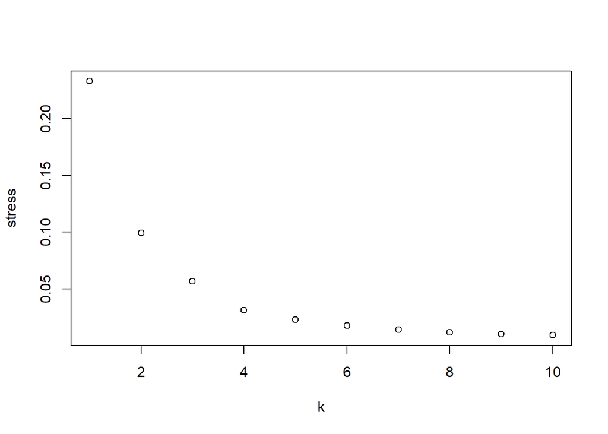

```r
plot(scree_out)
```

```r
# k=3 looks great
try.NMDS <- metaMDS(abundance_matrix, distance = "bray", k = 3, autotransform = TRUE, trymax=100)
```

```
## Square root transformation
## Wisconsin double standardization
## *** Best solution repeated 2 times
```

```r
# check the stress value. It should be < 0.2, ideally even < 0.05. (But too low stress values can indicate too many 0 values)
try.NMDS$stress
```

```
## [1] 0.05653636
```

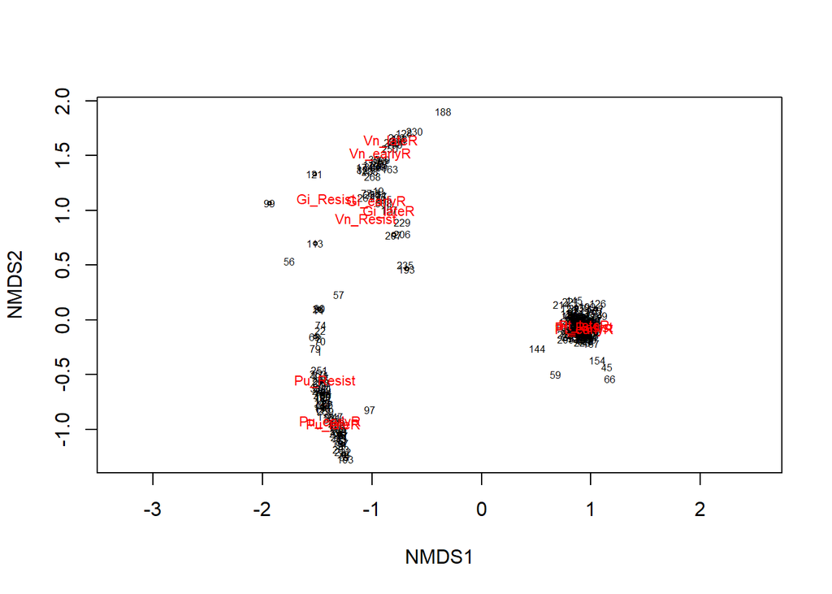

```r
# let's get a general idea of what this NMDS is separating...

# plot the results for axis 1 & 2
ordiplot(try.NMDS, type = "n") # create blank ordination plot
orditorp(try.NMDS, display = "sites", cex = 0.5, air = 0.1) # add row numbers in black
orditorp(try.NMDS, display = "species", col="red", air = 0.1) # add species names in red
```

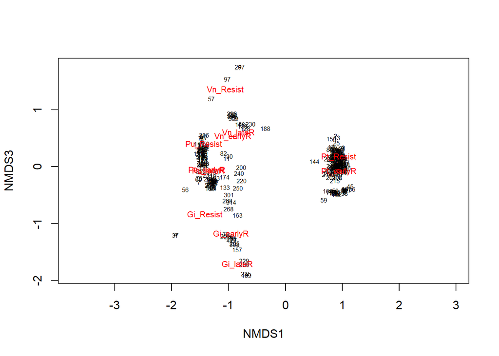

```r
# plot the results for axis 1 & 3
ordiplot(try.NMDS, choices = c(1,3), type = "n") # create blank ordination plot
orditorp(try.NMDS, choices = c(1,3), display = "sites", cex = 0.5, air = 0.1) # add row numbers in black
orditorp(try.NMDS, choices = c(1,3), display = "species", col="red", air = 0.1) # add species names in red
```

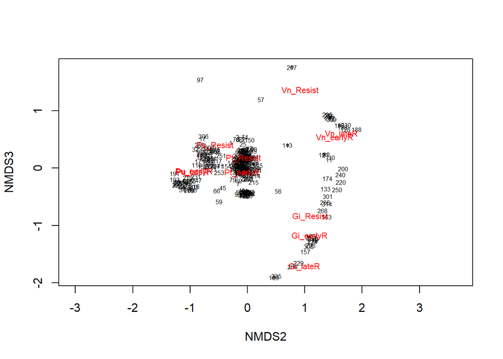

```r
# plot the results for axis 2 & 3
ordiplot(try.NMDS, choices = c(2,3), type = "n") # create blank ordination plot
orditorp(try.NMDS, choices = c(2,3), display = "sites", cex = 0.5, air = 0.1) # add row numbers in black
orditorp(try.NMDS, choices = c(2,3), display = "species", col="red", air = 0.1) # add species names in red
```

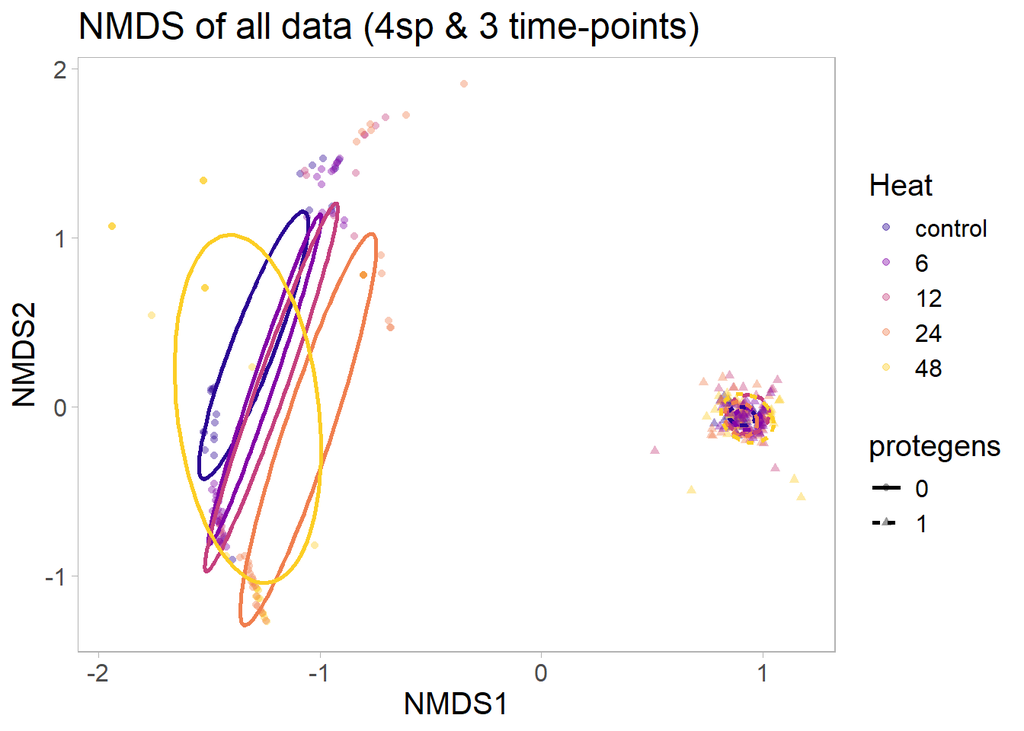

```r
# we already know that presense/absence of protegens is consistently the most important thing for all communities so let's see if that shows up here.
# Let's switch over to ggplot to be certain that everything is labelled correctly.

# define a function (related to vegan) that finds coordinates for drawing a covariance ellipse
  # CREDIT: THIS COMES FROM ONE OF THE TUTORIALS ABOVE!!!
veganCovEllipse <- function (cov, center = c(0, 0), scale = 1, npoints = 100) {
  theta <- (0:npoints) * 2 * pi/npoints
  Circle <- cbind(cos(theta), sin(theta))
  t(center + scale * t(Circle %*% chol(cov)))
  # finds the centroids and dispersion of the different ellipses based on a grouping factor of your choice
}

nmds_for_ggplot <- cbind(absDen_wide_forOrd[,1:8],
                         as.data.frame(scores(try.NMDS)$sites))
# create a new factor that defines the combination of heat and protegens
nmds_for_ggplot <- nmds_for_ggplot %>% unite("HeatxProtegens", c(Heat, protegens), remove = FALSE)
nmds_for_ggplot$HeatxProtegens <- factor(nmds_for_ggplot$HeatxProtegens,
                                         levels = c("6_0", "6_1", "12_0", "12_1", "24_0", "24_1", "48_0", "48_1", "control_0", "control_1"))



# create empty dataframes to combine NMDS data with ellipse data
ellipse12_df <- ellipse13_df <- ellipse23_df <- data.frame() # numbers indicate the ordination axes
# adding data for ellipses, using HeatxProtegens as a grouping factor
for(g in levels(nmds_for_ggplot$HeatxProtegens)){
  ellipse12_df <- rbind(ellipse12_df, cbind(as.data.frame(with(nmds_for_ggplot[nmds_for_ggplot$HeatxProtegens==g,],
                                                     veganCovEllipse(cov.wt(cbind(NMDS1, NMDS2),
                                                                            wt=rep(1/length(NMDS1),length(NMDS1)))$cov,
                                                                     center=c(mean(NMDS1),mean(NMDS2)))))
                                  , HeatxProtegens=g))
  ellipse13_df <- rbind(ellipse13_df, cbind(as.data.frame(with(nmds_for_ggplot[nmds_for_ggplot$HeatxProtegens==g,],
                                                     veganCovEllipse(cov.wt(cbind(NMDS1, NMDS3),
                                                                            wt=rep(1/length(NMDS1),length(NMDS1)))$cov,
                                                                     center=c(mean(NMDS1),mean(NMDS3)))))
                                  , HeatxProtegens=g))
  ellipse23_df <- rbind(ellipse23_df, cbind(as.data.frame(with(nmds_for_ggplot[nmds_for_ggplot$HeatxProtegens==g,],
                                                     veganCovEllipse(cov.wt(cbind(NMDS2, NMDS3),
                                                                            wt=rep(1/length(NMDS2),length(NMDS2)))$cov,
                                                                     center=c(mean(NMDS2),mean(NMDS3)))))
                                  , HeatxProtegens=g))
}

# now we separate the HeatxProtegens columns:
ellipse12_df <- ellipse12_df %>% separate(HeatxProtegens, c("Heat", "protegens"))
ellipse12_df$Heat <- factor(ellipse12_df$Heat, levels = levels(nmds_for_ggplot$Heat))
ellipse13_df <- ellipse13_df %>% separate(HeatxProtegens, c("Heat", "protegens"))
ellipse13_df$Heat <- factor(ellipse13_df$Heat, levels = levels(nmds_for_ggplot$Heat))
ellipse23_df <- ellipse23_df %>% separate(HeatxProtegens, c("Heat", "protegens"))
ellipse23_df$Heat <- factor(ellipse23_df$Heat, levels = levels(nmds_for_ggplot$Heat))

nmds_for_ggplot$protegens <- as.character(nmds_for_ggplot$protegens) # this needs to be discrete (could also be a factor)

# and finally we can make the plots:
ggplot(data = nmds_for_ggplot, aes(NMDS1, NMDS2)) +
    geom_point(aes(color = Heat, shape = protegens), alpha=0.4) + # adding different colours and shapes for points at different distances
    geom_path(data=ellipse12_df, aes(x=NMDS1, y=NMDS2, colour=Heat, linetype=protegens), linewidth=1) + # adding covariance ellipses according to distance # use size argument if ggplot2 < v. 3.4.0
    guides(color = guide_legend(override.aes = list(linetype=rep(NA,5)))) + # removes lines from colour part of the legend
    scale_colour_viridis_d(option = "plasma", begin=0.05, end = 0.9) +
    fave_theme + # not sure why I need this but I do to over-write the default grey theme
    labs(title="NMDS of all data (4sp & 3 time-points)")
```

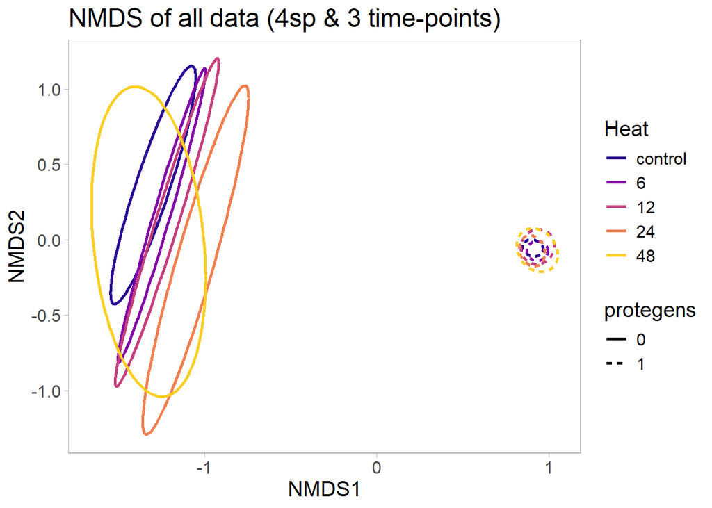

```r
# axes 1 & 2 again showing just the ellipses (bc it's hard to see protegens effects as it's so overlapped)
ggplot(data = nmds_for_ggplot, aes(NMDS1, NMDS2)) +
    geom_path(data=ellipse12_df, aes(x=NMDS1, y=NMDS2, colour=Heat, linetype=protegens), linewidth=1) + # plot just the ellipses
    scale_colour_viridis_d(option = "plasma", begin=0.05, end = 0.9) +
    fave_theme + # not sure why I need this but I do to over-write the default grey theme
    labs(title="NMDS of all data (4sp & 3 time-points)")
```

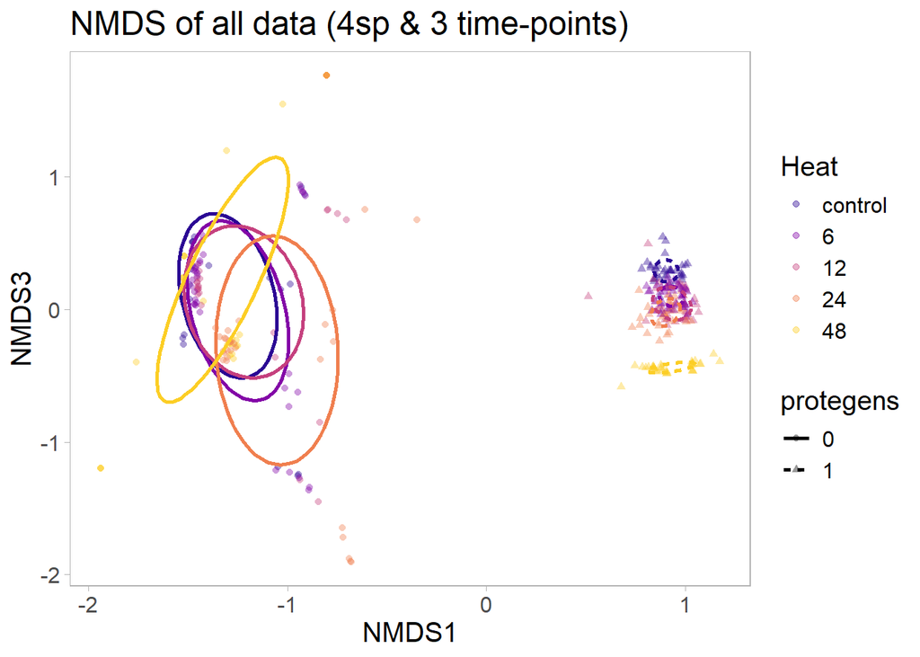

```r
ggplot(data = nmds_for_ggplot, aes(NMDS1, NMDS3)) +
    geom_point(aes(color = Heat, shape = protegens), alpha=0.4) +
    geom_path(data=ellipse13_df, aes(x=NMDS1, y=NMDS3, colour=Heat, linetype=protegens), linewidth=1) +
    guides(color = guide_legend(override.aes = list(linetype=rep(NA,5)))) +
    scale_colour_viridis_d(option = "plasma", begin=0.05, end = 0.9) +
    fave_theme +
    labs(title="NMDS of all data (4sp & 3 time-points)")
```

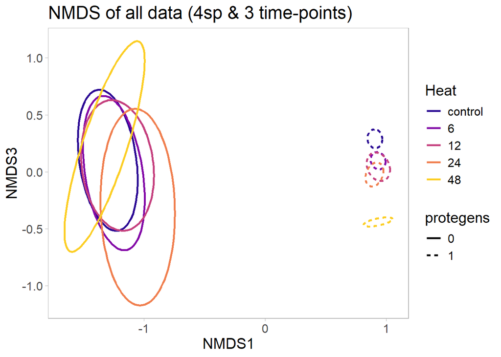

```r
# axes 1 & 3 again showing just the ellipses
ggplot(data = nmds_for_ggplot, aes(NMDS1, NMDS3)) +
    geom_path(data=ellipse13_df, aes(x=NMDS1, y=NMDS3, colour=Heat, linetype=protegens), linewidth=1) +
    scale_colour_viridis_d(option = "plasma", begin=0.05, end = 0.9) +
    fave_theme +
    labs(title="NMDS of all data (4sp & 3 time-points)")
```

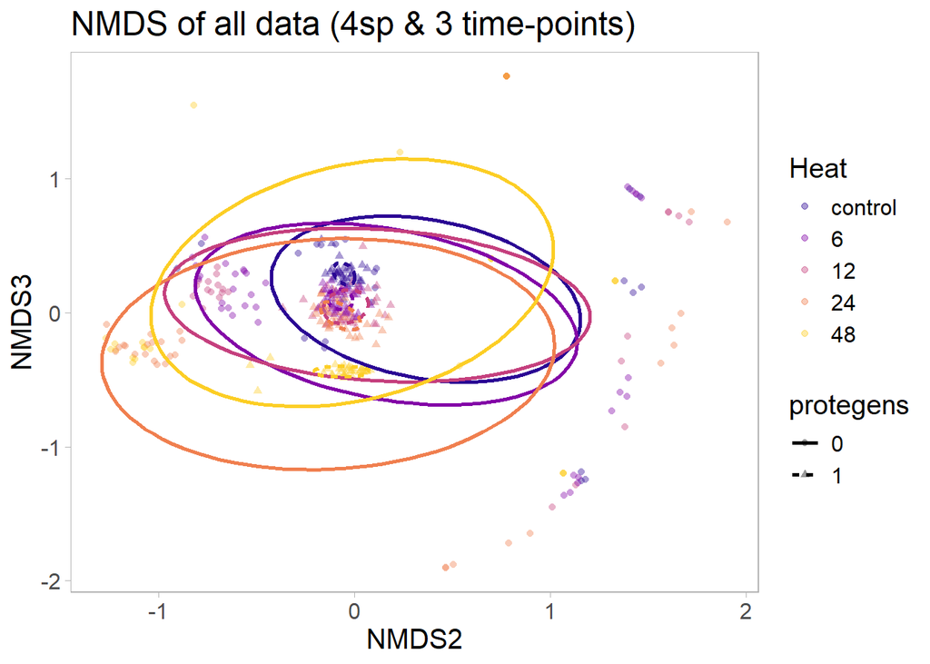

```r
ggplot(data = nmds_for_ggplot, aes(NMDS2, NMDS3)) +
    geom_point(aes(color = Heat, shape = protegens), alpha=0.4) +
    geom_path(data=ellipse23_df, aes(x=NMDS2, y=NMDS3, colour=Heat, linetype=protegens), linewidth=1) +
    guides(color = guide_legend(override.aes = list(linetype=rep(NA,5)))) +
    scale_colour_viridis_d(option = "plasma", begin=0.05, end = 0.9) +
    fave_theme +
    labs(title="NMDS of all data (4sp & 3 time-points)")
```

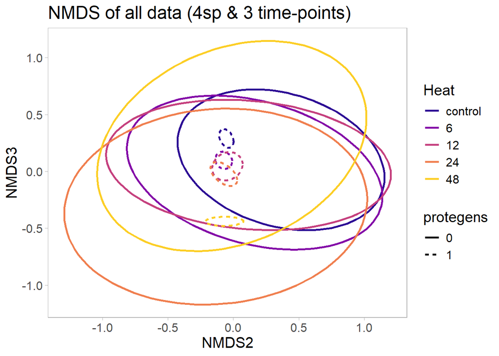

```r
# axes 2 & 3 again showing just the ellipses (bc it's hard to see protegens effects as it's so overlapped)
ggplot(data = nmds_for_ggplot, aes(NMDS2, NMDS3)) +
    geom_path(data=ellipse23_df, aes(x=NMDS2, y=NMDS3, colour=Heat, linetype=protegens), linewidth=1) +
    scale_colour_viridis_d(option = "plasma", begin=0.05, end = 0.9) +
    fave_theme +
    labs(title="NMDS of all data (4sp & 3 time-points)")
```

```r
################
# check significance:
# using a PERMANOVA to test the differences in community composition
# This is a PERmutational Multivariate ANalysis Of VAriance and tests the differences between groups, like an ANOVA, but with lots of variables.
# it is essentially a multivariate analysis of variance used to compare groups of objects
nmdsdata_test_Heat <- adonis2(abundance_matrix ~ Heat, absDen_wide_forOrd,
                              permutations = 999, method = "bray")
print(nmdsdata_test_Heat)
```

```
## Permutation test for adonis under reduced model
## Permutation: free
## Number of permutations: 999
##
## adonis2(formula = abundance_matrix ~ Heat, data = absDen_wide_forOrd, permutations = 999, method = "bray")
##           Df SumOfSqs      R2      F Pr(>F)
## Model      4    8.188 0.07534 6.4981  0.001 ***
## Residual 319  100.485 0.92466
## Total    323  108.673 1.00000
## ---
## Signif. codes:  0 '***' 0.001 '**' 0.01 '*' 0.05 '.' 0.1 ' ' 1
```

```r
nmdsdata_test_Prot <- adonis2(abundance_matrix ~ protegens, absDen_wide_forOrd,
                              permutations = 999, method = "bray")
print(nmdsdata_test_Prot)
```

```
## Permutation test for adonis under reduced model
## Permutation: free
## Number of permutations: 999
##
## adonis2(formula = abundance_matrix ~ protegens, data = absDen_wide_forOrd, permutations = 999, method = "bray")
##           Df SumOfSqs      R2      F Pr(>F)
## Model      1   45.211 0.41603 229.39  0.001 ***
## Residual 322   63.462 0.58397
## Total    323  108.673 1.00000
## ---
## Signif. codes:  0 '***' 0.001 '**' 0.01 '*' 0.05 '.' 0.1 ' ' 1
```

```r
nmdsdata_test_HeatxProt <- adonis2(abundance_matrix ~ Heat * protegens, absDen_wide_forOrd,
                                   permutations = 999, method = "bray")
print(nmdsdata_test_HeatxProt)
```

```
## Permutation test for adonis under reduced model
## Permutation: free
## Number of permutations: 999
##
## adonis2(formula = abundance_matrix ~ Heat * protegens, data = absDen_wide_forOrd, permutations = 999, method = "bray")
##           Df SumOfSqs      R2      F Pr(>F)
## Model      9   60.966 0.56101 44.586  0.001 ***
## Residual 314   47.706 0.43899
## Total    323  108.673 1.00000
## ---
## Signif. codes:  0 '***' 0.001 '**' 0.01 '*' 0.05 '.' 0.1 ' ' 1
```

```r
# so these are all significant but is that spurious because the dispersion is different btw groups? (e.g., much smaller for protegens)

##############
# check PERMANOVA assumption of homogeneous group variances
# Bray-curtis distance matrix
dist_mat <- vegdist(abundance_matrix, method = "bray")

# use betadisper test to check for multivariate homogeneity of group variances
dispersion <- betadisper(dist_mat, group = paste(absDen_wide_forOrd$Heat, absDen_wide_forOrd$protegens))
permutest(dispersion)
```

```
##
## Permutation test for homogeneity of multivariate dispersions
## Permutation: free
## Number of permutations: 999
##
## Response: Distances
##            Df  Sum Sq Mean Sq      F N.Perm Pr(>F)
## Groups      9  8.7974 0.97749 23.077    999  0.001 ***
## Residuals 314 13.3006 0.04236
## ---
## Signif. codes:  0 '***' 0.001 '**' 0.01 '*' 0.05 '.' 0.1 ' ' 1
```

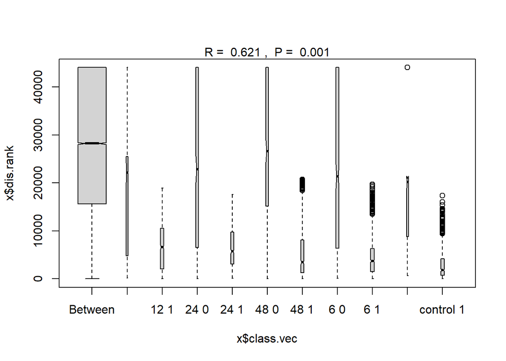

```r
# yeap! We need to try a different test that is robust to heterogenous group variances...

################
# check significance:
# let's test for significance again using ANOSIM (which is another non-parametric test but this time only considering the ranks)
nmdsdata_test2_HeatxProt <- anosim(dist_mat,
                                   grouping = paste(absDen_wide_forOrd$Heat, absDen_wide_forOrd$protegens),
                                   permutations = 999)
plot(nmdsdata_test2_HeatxProt)
```

```r
summary(nmdsdata_test2_HeatxProt)
```

```
##
## Call:
## anosim(x = dist_mat, grouping = paste(absDen_wide_forOrd$Heat,      absDen_wide_forOrd$protegens), permutations = 999)
## Dissimilarity: bray
##
## ANOSIM statistic R: 0.6212
##       Significance: 0.001
##
## Permutation: free
## Number of permutations: 999
##
## Upper quantiles of permutations (null model):
##    90%    95%  97.5%    99%
## 0.0110 0.0150 0.0173 0.0204
##
## Dissimilarity ranks between and within classes:
##              0%      25%     50%     75%    100%     N
## Between    15.5 15656.00 28220.0 44062.5 44062.5 47065
## 12 0      156.0  4841.00 22156.0 25514.0 44062.5   253
## 12 1       37.0  2073.25  6635.0 10519.0 18965.0   780
## 24 0       15.5  6506.00 22860.0 44062.5 44062.5   465
## 24 1      102.0  3052.00  5746.0  9735.5 17602.0   595
## 48 0       15.5 15176.00 26611.5 44062.5 44062.5   406
## 48 1       33.0  1305.00  3454.0  8128.5 20766.0   595
## 6 0        88.0  6343.00 21367.0 44062.5 44062.5   561
## 6 1        35.0  1550.50  3749.0  6333.5 19718.0   780
## control 0 685.0  8820.00 20181.0 20994.5 44062.5   231
## control 1  32.0   729.00  1856.0  4199.5 17322.0   595
```

Great!, This summarizes the same result that I found with the other indices: presence of P.protegens is the most important thing. Communities where this species was present look quite similar across different heat treatments. Longer heat durations push the communities toward different direction, until a threshold is reached at the longest heat treatment (48h).

The NMDS ordination results are significant by PERMANOVA but the assumptions of that test might be violated because the dispersal is heterogeneous between groups. I think ANOSIM should be somewhat more robust to this problem because it uses ranks. The NMDS ordination results are significant by ANOSIM.

```r
################################
# Plot figure for main text: Figure 3b
################################
# change protegens values for better plotting
nmds_for_ggplot$P_protegens <- "absent"
nmds_for_ggplot$P_protegens[nmds_for_ggplot$protegens == 1] <- "present"

ellipse12_df$P_protegens <- "absent"
ellipse12_df$P_protegens[ellipse12_df$protegens == 1] <- "present"

ellipse13_df$P_protegens <- "absent"
ellipse13_df$P_protegens[ellipse13_df$protegens == 1] <- "present"

# change Heat values for better plotting
levels(nmds_for_ggplot$Heat)[2:5] <- paste(levels(nmds_for_ggplot$Heat)[2:5], "hrs")
levels(ellipse12_df$Heat)[2:5] <- paste(levels(ellipse12_df$Heat)[2:5], "hrs")
levels(ellipse13_df$Heat)[2:5] <- paste(levels(ellipse13_df$Heat)[2:5], "hrs")

# create the plot of 1 vs 2:
plot1_2 <- ggplot(data = nmds_for_ggplot, aes(NMDS1, NMDS2)) +
            geom_point(aes(color = Heat, shape = P_protegens), size=2, alpha=0.4) + # adding different colours and shapes for points at different distances
            geom_path(data=ellipse12_df, aes(x=NMDS1, y=NMDS2, colour=Heat, linetype=P_protegens), linewidth=1) + # adding covariance ellipses according to distance # use size argument if ggplot2 < v. 3.4.0
            guides(color = guide_legend(override.aes = list(linetype=rep(NA,5),# removes lines from colour part of the legend
                                                  alpha=1, size=3)), # make the points opaque and bigger in the colour part of the legend
            shape = guide_legend(override.aes = list(size=3))) + # make the points bigger in the greyscale part of the legend
            scale_colour_viridis_d(option = "plasma", begin=0.05, end = 0.9)

# plot 1 vs 2 with the legend ... I will extract the legend from here
png(filename="./figures/Fig3_A_legend.png", width = 3.48, height = 3.41, units = "in", res=300)
print(plot1_2)
dev.off()
```

```r
# plot 1 vs 2 without the legend
png(filename="./figures/Fig3_A_axis1vs2.png", width = 5.35, height = 3.78, units = "in", res=300)
print(plot1_2 + theme(legend.position="none"))
dev.off()
```

```r
# plot 1 vs 3 without the legend
png(filename="./figures/Fig3_A_axis1vs3.png", width = 5.35, height = 3.78, units = "in", res=300)

ggplot(data = nmds_for_ggplot, aes(NMDS1, NMDS3)) +
    geom_point(aes(color = Heat, shape = P_protegens), size=2, alpha=0.4) +
    geom_path(data=ellipse13_df, aes(x=NMDS1, y=NMDS3, colour=Heat, linetype=P_protegens), linewidth=1) +
    scale_colour_viridis_d(option = "plasma", begin=0.05, end = 0.9) +
    theme(legend.position="none")

dev.off()
```

## Gradient with 48h

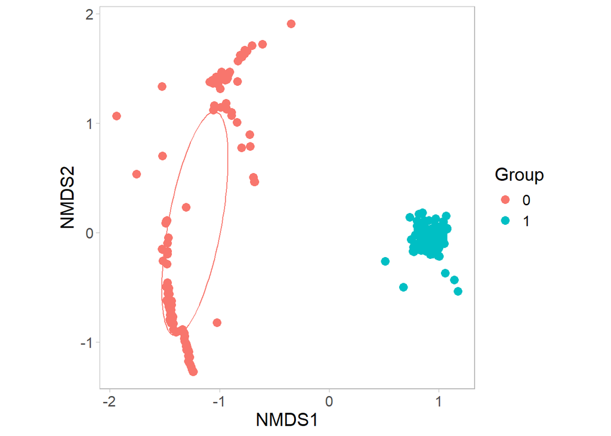

```r
# let's check if the gradient of heat pulse duration is significant:
absDen_wide_forOrd$Heat <- as.character(levels(absDen_wide_forOrd$Heat))[absDen_wide_forOrd$Heat]
absDen_wide_forOrd$Heat[absDen_wide_forOrd$Heat == "control"] <- 0
absDen_wide_forOrd$Heat <- as.numeric(absDen_wide_forOrd$Heat)

# let's see what the heat gradient looks like
gg_ordiplot(try.NMDS, groups = absDen_wide_forOrd$protegens, plot = TRUE)
```

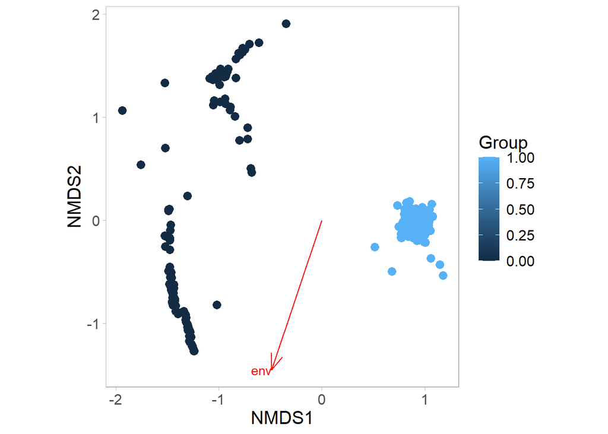

```r
# here's another way to do it:
gg_envfit(try.NMDS, env = absDen_wide_forOrd$Heat, groups = absDen_wide_forOrd$protegens, plot = TRUE, alpha=0.5) # notice this gradient is not significant!!!
```

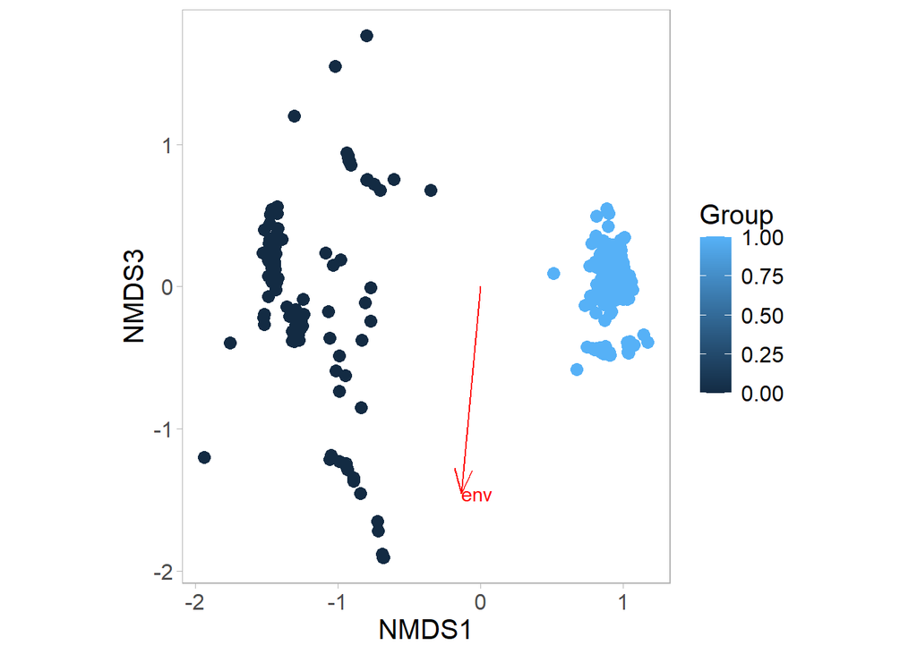

```r
gg_envfit(try.NMDS, env = absDen_wide_forOrd$Heat, groups = absDen_wide_forOrd$protegens, plot = TRUE, alpha=0.5, choices=c(1,3)) # notice this gradient is not significant!!!
```

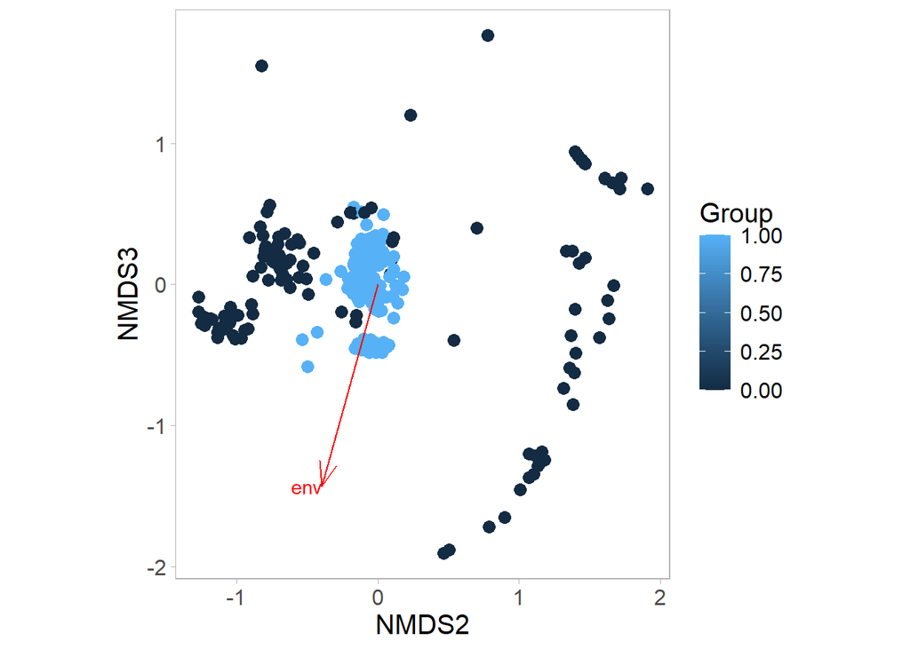

```r
gg_envfit(try.NMDS, env = absDen_wide_forOrd$Heat, groups = absDen_wide_forOrd$protegens, plot = TRUE, alpha=0.5, choices=c(2,3)) # notice this gradient is not significant!!!
```

```r
# display the p-value:
gg_envfit(try.NMDS, env = absDen_wide_forOrd$Heat, groups = absDen_wide_forOrd$protegens, alpha=0.5, plot = FALSE)$df_arrows$p.val
```

```
## [1] 0.295
```

The gradient is *NOT* significant.

## Gradient without 48h

Let’s re-do the analysis this time removing the 48h duration in order to check if the gradient becomes significant.

```r
# exclude 48h duration data
absDen_wide_forOrd_no48 <- absDen_wide_forOrd %>% filter(Heat < 48)
abundance_mat_no48 <- as.matrix(absDen_wide_forOrd_no48[,9:20])
# re-do the NMDS with k=3
NMDS_no48 <- metaMDS(abundance_mat_no48, distance = "bray", k = 3, autotransform = TRUE, trymax=100)
```

```
## Square root transformation
## Wisconsin double standardization
## *** Best solution repeated 1 times
```

```r
# check the stress value. For the data with 48h it was 0.05653636
NMDS_no48$stress # it's smaller than before
```

```
## [1] 0.03585661
```

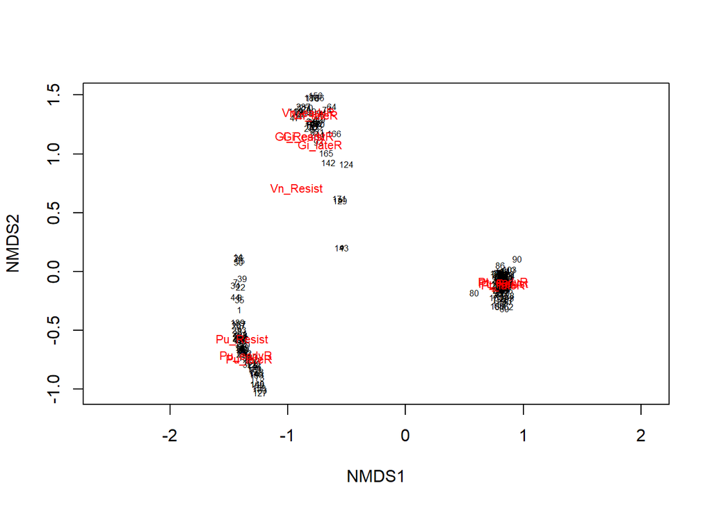

```r
# let's get a general idea of what this NMDS is separating...
# plot the results for axis 1 & 2
ordiplot(NMDS_no48, type = "n") # create blank ordination plot
orditorp(NMDS_no48, display = "sites", cex = 0.5, air = 0.1) # add row numbers in black
orditorp(NMDS_no48, display = "species", col="red", air = 0.1) # add species names in red
```

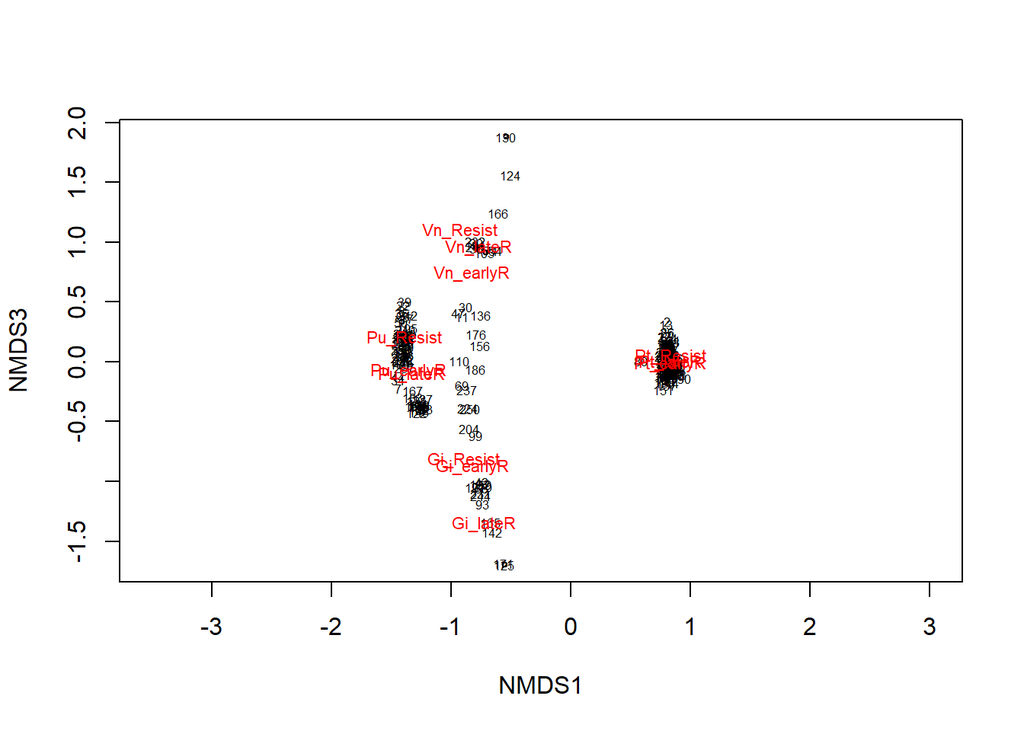

```r
# plot the results for axis 1 & 3
ordiplot(NMDS_no48, choices = c(1,3), type = "n") # create blank ordination plot
orditorp(NMDS_no48, choices = c(1,3), display = "sites", cex = 0.5, air = 0.1) # add row numbers in black
orditorp(NMDS_no48, choices = c(1,3), display = "species", col="red", air = 0.1) # add species names in red
```

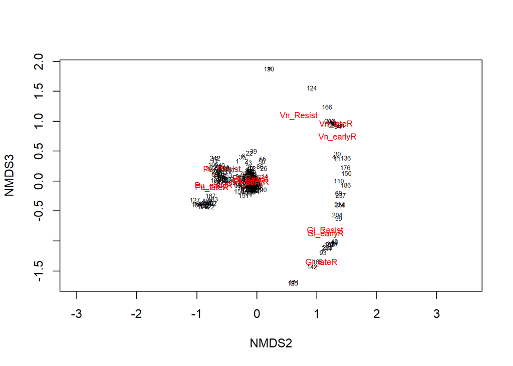

```r
# plot the results for axis 2 & 3
ordiplot(NMDS_no48, choices = c(2,3), type = "n") # create blank ordination plot
orditorp(NMDS_no48, choices = c(2,3), display = "sites", cex = 0.5, air = 0.1) # add row numbers in black
orditorp(NMDS_no48, choices = c(2,3), display = "species", col="red", air = 0.1) # add species names in red
```

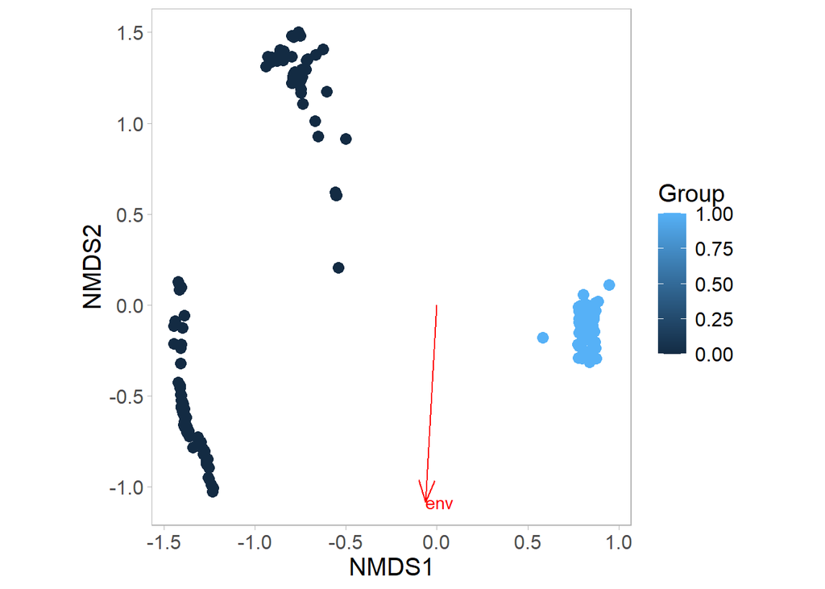

```r
# test for significance
gg_envfit(NMDS_no48, env = absDen_wide_forOrd_no48$Heat, groups = absDen_wide_forOrd_no48$protegens, plot = TRUE, alpha=0.5)
```

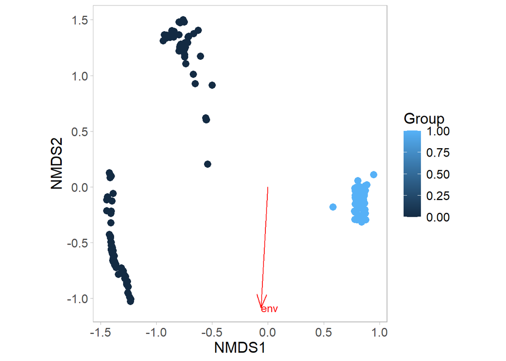

```
## [1] 0.224
```

```r
gg_envfit(NMDS_no48, env = absDen_wide_forOrd_no48$Heat, groups = absDen_wide_forOrd_no48$protegens, plot = TRUE, alpha=0.5)$df_arrows$p.val
```

The NMDS looks similar to when the 48h heat pulse data was included. But it’s not exactly the same, as is to be expected. The gradient is *NOT* significant when we remove all of the 48h heat pulse duration data.

## Gradient with 48h protegens but none of the 48h others

```r
# exclude 48h duration data
absDen_wide_forOrd_no48 <- rbind(absDen_wide_forOrd %>% filter(Heat < 48),
                                 absDen_wide_forOrd %>% filter(Heat == 48, protegens == 1))
abundance_mat_no48 <- as.matrix(absDen_wide_forOrd_no48[,9:20])
# re-do the NMDS with k=3
NMDS_no48 <- metaMDS(abundance_mat_no48, distance = "bray", k = 3, autotransform = TRUE, trymax=100)
```

```
## Square root transformation
## Wisconsin double standardization
## *** Best solution repeated 1 times
```

```r
# check the stress value. For the data with 48h it was 0.05653636
NMDS_no48$stress # it's smaller than before
```

```
## [1] 0.0370302
```

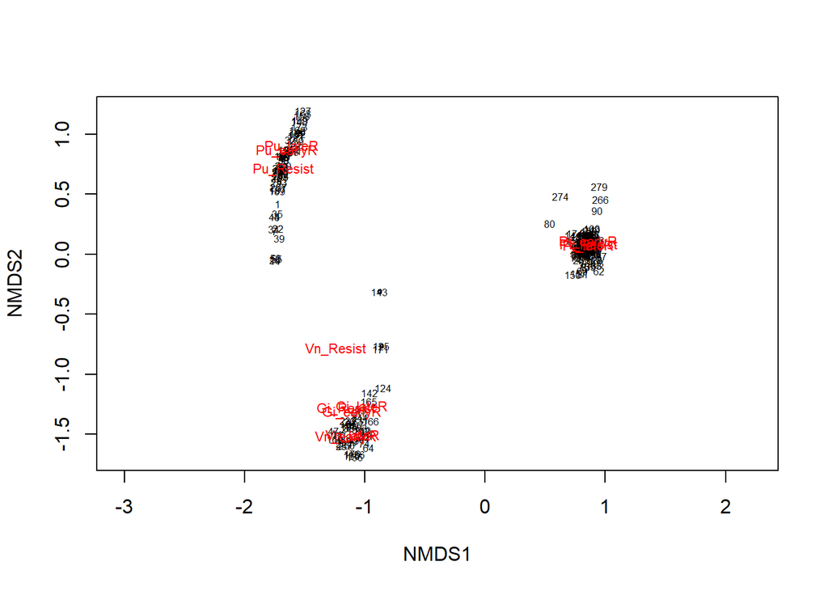

```r
# let's get a general idea of what this NMDS is separating...
# plot the results for axis 1 & 2
ordiplot(NMDS_no48, type = "n") # create blank ordination plot
orditorp(NMDS_no48, display = "sites", cex = 0.5, air = 0.1) # add row numbers in black
orditorp(NMDS_no48, display = "species", col="red", air = 0.1) # add species names in red
```

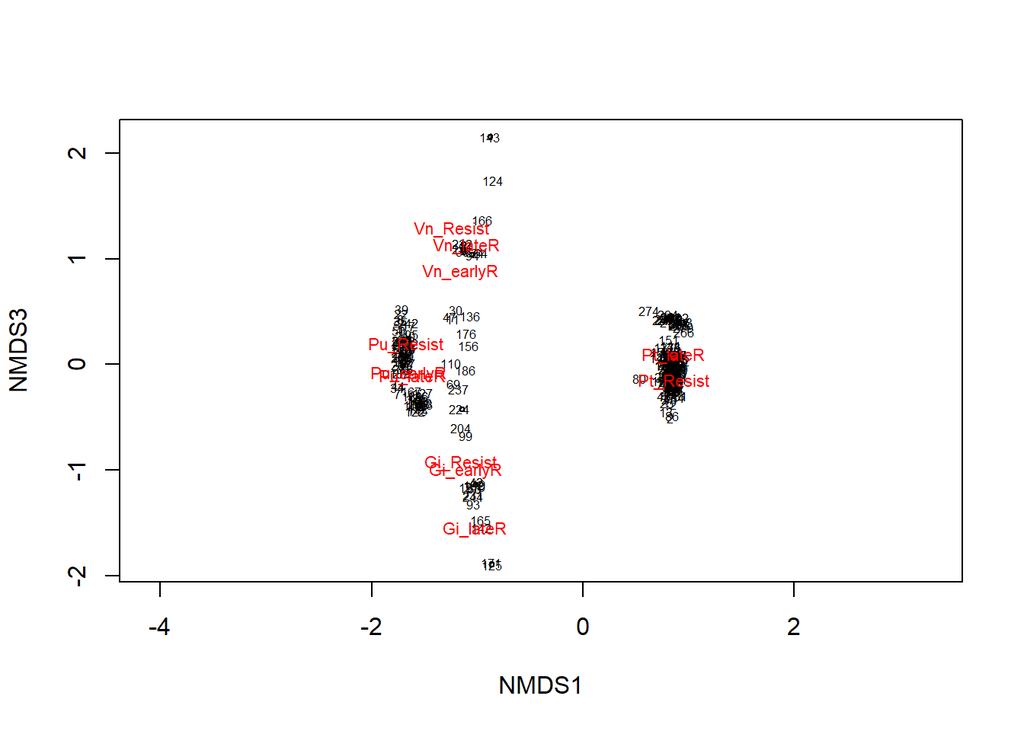

```r
# plot the results for axis 1 & 3
ordiplot(NMDS_no48, choices = c(1,3), type = "n") # create blank ordination plot
orditorp(NMDS_no48, choices = c(1,3), display = "sites", cex = 0.5, air = 0.1) # add row numbers in black
orditorp(NMDS_no48, choices = c(1,3), display = "species", col="red", air = 0.1) # add species names in red
```

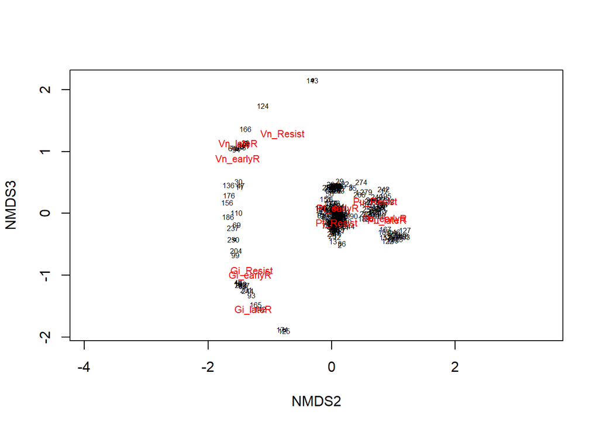

```r
# plot the results for axis 2 & 3
ordiplot(NMDS_no48, choices = c(2,3), type = "n") # create blank ordination plot
orditorp(NMDS_no48, choices = c(2,3), display = "sites", cex = 0.5, air = 0.1) # add row numbers in black
orditorp(NMDS_no48, choices = c(2,3), display = "species", col="red", air = 0.1) # add species names in red
```

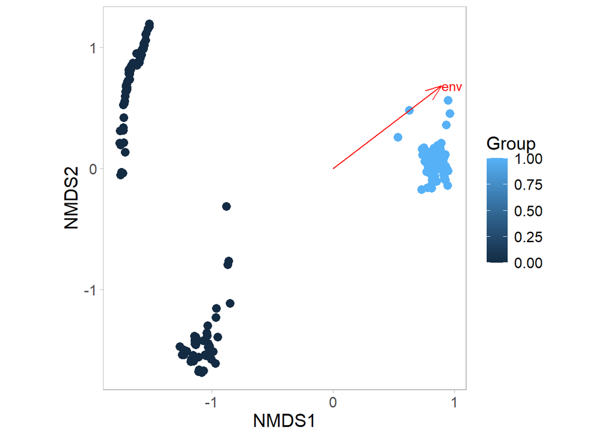

```r
# test for significance of environmental vector:
gg_envfit(NMDS_no48, env = absDen_wide_forOrd_no48$Heat, groups = absDen_wide_forOrd_no48$protegens, plot = TRUE)
```

```r
# extract values about the environmental vector
temp <- gg_envfit(NMDS_no48, env = absDen_wide_forOrd_no48$Heat, groups = absDen_wide_forOrd_no48$protegens, plot = FALSE)
# print out the p-value:
print(temp$df_arrows$p.val)
```

```
## [1] 0.001
```

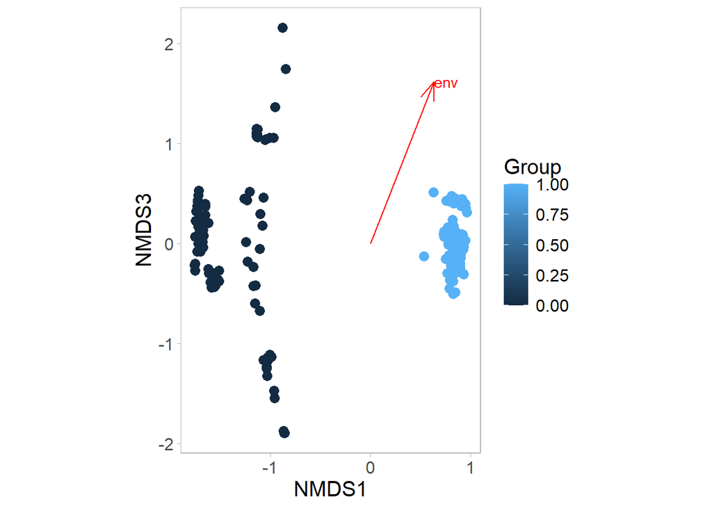

```r
# save the coordinates of the arrow
arrow_1vs2 <- c(x = temp$df_arrows$x,
                y = temp$df_arrows$y)

# repeat for axis 1 vs 3
gg_envfit(NMDS_no48, env = absDen_wide_forOrd_no48$Heat, groups = absDen_wide_forOrd_no48$protegens, plot = TRUE, choices=c(1,3))
```

```r
# extract values about the environmental vector
temp <- gg_envfit(NMDS_no48, env = absDen_wide_forOrd_no48$Heat, groups = absDen_wide_forOrd_no48$protegens, plot = FALSE, choices=c(1,3))
# print out the p-value:
print(temp$df_arrows$p.val)
```

```
## [1] 0.001
```

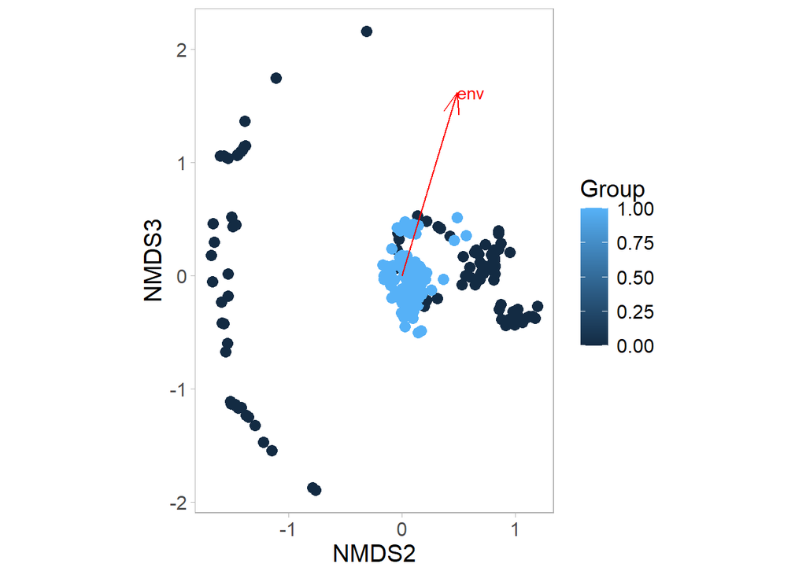

```r
# save the coordinates of the arrow
arrow_1vs3 <- c(x = temp$df_arrows$x,
                y = temp$df_arrows$y)

# repeat for axis 2 vs 3
gg_envfit(NMDS_no48, env = absDen_wide_forOrd_no48$Heat, groups = absDen_wide_forOrd_no48$protegens, plot = TRUE, choices=c(2,3))
```

```r
# extract values about the environmental vector
temp <- gg_envfit(NMDS_no48, env = absDen_wide_forOrd_no48$Heat, groups = absDen_wide_forOrd_no48$protegens, plot = FALSE, choices=c(2,3))
# print out the p-value just in case it's different:
print(temp$df_arrows$p.val)
```

```
## [1] 0.001
```

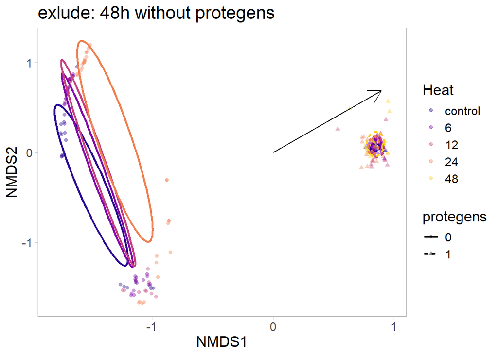

```r
# save the coordinates of the arrow
arrow_2vs3 <- c(x = temp$df_arrows$x,
                y = temp$df_arrows$y)


# okay now that we see this is significant, let's make a pretty plot of the NMDS to include in the supplement
  # first we have to return Heat to a factor with appropriate levels
absDen_wide_forOrd_no48$Heat <- factor(absDen_wide_forOrd_no48$Heat,
                                       levels = c(0, 6, 12, 24, 48))
levels(absDen_wide_forOrd_no48$Heat)[1] <- "control"


nmds_for_ggplot <- cbind(absDen_wide_forOrd_no48[,1:8],
                         as.data.frame(scores(NMDS_no48)$sites))

# create a new factor that defines the combination of heat and protegens
nmds_for_ggplot <- nmds_for_ggplot %>% unite("HeatxProtegens", c(Heat, protegens), remove = FALSE)
nmds_for_ggplot$HeatxProtegens <- factor(nmds_for_ggplot$HeatxProtegens,
                                         levels = c("6_0", "6_1", "12_0", "12_1", "24_0", "24_1", "48_1", "control_0", "control_1"))



# create empty dataframes to combine NMDS data with ellipse data
ellipse12_df <- ellipse13_df <- ellipse23_df <- data.frame() # numbers indicate the ordination axes
# adding data for ellipses, using HeatxProtegens as a grouping factor
for(g in levels(nmds_for_ggplot$HeatxProtegens)){
  ellipse12_df <- rbind(ellipse12_df, cbind(as.data.frame(with(nmds_for_ggplot[nmds_for_ggplot$HeatxProtegens==g,],
                                                     veganCovEllipse(cov.wt(cbind(NMDS1, NMDS2),
                                                                            wt=rep(1/length(NMDS1),length(NMDS1)))$cov,
                                                                     center=c(mean(NMDS1),mean(NMDS2)))))
                                  , HeatxProtegens=g))
  ellipse13_df <- rbind(ellipse13_df, cbind(as.data.frame(with(nmds_for_ggplot[nmds_for_ggplot$HeatxProtegens==g,],
                                                     veganCovEllipse(cov.wt(cbind(NMDS1, NMDS3),
                                                                            wt=rep(1/length(NMDS1),length(NMDS1)))$cov,
                                                                     center=c(mean(NMDS1),mean(NMDS3)))))
                                  , HeatxProtegens=g))
  ellipse23_df <- rbind(ellipse23_df, cbind(as.data.frame(with(nmds_for_ggplot[nmds_for_ggplot$HeatxProtegens==g,],
                                                     veganCovEllipse(cov.wt(cbind(NMDS2, NMDS3),
                                                                            wt=rep(1/length(NMDS2),length(NMDS2)))$cov,
                                                                     center=c(mean(NMDS2),mean(NMDS3)))))
                                  , HeatxProtegens=g))
}

# now we separate the HeatxProtegens columns:
ellipse12_df <- ellipse12_df %>% separate(HeatxProtegens, c("Heat", "protegens"))
ellipse12_df$Heat <- factor(ellipse12_df$Heat,
                            levels(nmds_for_ggplot$Heat))
ellipse13_df <- ellipse13_df %>% separate(HeatxProtegens, c("Heat", "protegens"))
ellipse13_df$Heat <- factor(ellipse13_df$Heat, levels = levels(nmds_for_ggplot$Heat))
ellipse23_df <- ellipse23_df %>% separate(HeatxProtegens, c("Heat", "protegens"))
ellipse23_df$Heat <- factor(ellipse23_df$Heat, levels = levels(nmds_for_ggplot$Heat))

nmds_for_ggplot$protegens <- as.character(nmds_for_ggplot$protegens) # this needs to be discrete (could also be a factor)

# and finally we can make the plots:
ggplot(data = nmds_for_ggplot, aes(NMDS1, NMDS2)) +
    geom_point(aes(color = Heat, shape = protegens), alpha=0.4) + # adding different colours and shapes for points at different distances
    geom_path(data=ellipse12_df, aes(x=NMDS1, y=NMDS2, colour=Heat, linetype=protegens), linewidth=1) + # adding covariance ellipses according to distance # use size argument if ggplot2 < v. 3.4.0
    guides(color = guide_legend(override.aes = list(linetype=rep(NA,5)))) + # removes lines from colour part of the legend
    scale_colour_viridis_d(option = "plasma", begin=0.05, end = 0.9) +
    geom_segment(aes(x = 0, y = 0,
                     xend = arrow_1vs2["x"], yend = arrow_1vs2["y"]),
                  arrow = arrow(length = unit(0.5, "cm")),
                 linewidth = 0.5) +
    fave_theme + # not sure why I need this but I do to over-write the default grey theme
    labs(title="exlude: 48h without protegens")
```

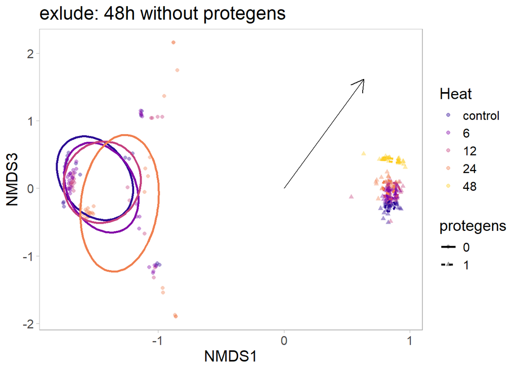

```r
# axis 1 vs 3
ggplot(data = nmds_for_ggplot, aes(NMDS1, NMDS3)) +
    geom_point(aes(color = Heat, shape = protegens), alpha=0.4) +
    geom_path(data=ellipse13_df, aes(x=NMDS1, y=NMDS3, colour=Heat, linetype=protegens), linewidth=1) +
    guides(color = guide_legend(override.aes = list(linetype=rep(NA,5)))) +
    scale_colour_viridis_d(option = "plasma", begin=0.05, end = 0.9) +
    geom_segment(aes(x = 0, y = 0,
                     xend = arrow_1vs3["x"], yend = arrow_1vs3["y"]),
                  arrow = arrow(length = unit(0.5, "cm")),
                 linewidth = 0.5) +
    fave_theme +
    labs(title="exlude: 48h without protegens")
```

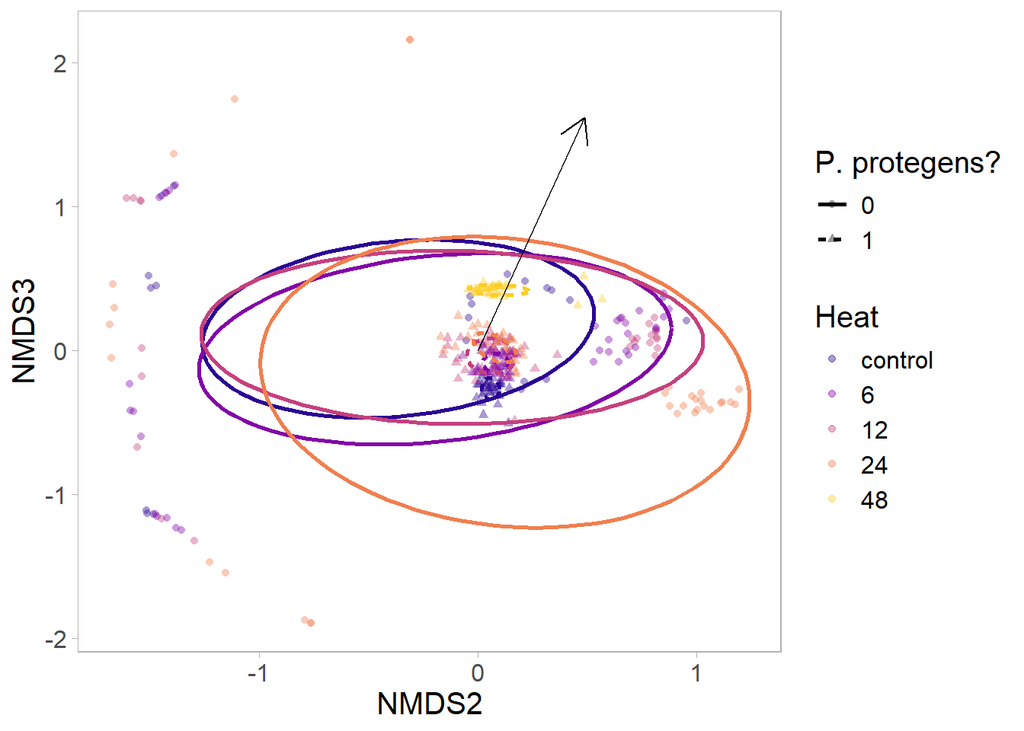

```r
# axis 2 vs 3
ggplot(data = nmds_for_ggplot, aes(NMDS2, NMDS3)) +
    geom_point(aes(color = Heat, shape = protegens), alpha=0.4) +
    geom_path(data=ellipse23_df, aes(x=NMDS2, y=NMDS3, colour=Heat, linetype=protegens), linewidth=1) +
    guides(color = guide_legend(override.aes = list(linetype=rep(NA,5)))) +
    scale_colour_viridis_d(option = "plasma", begin=0.05, end = 0.9) +
    geom_segment(aes(x = 0, y = 0,
                     xend = arrow_2vs3["x"], yend = arrow_2vs3["y"]),
                  arrow = arrow(length = unit(0.5, "cm")),
                 linewidth = 0.5) +
    fave_theme +
    labs(colour = "Heat",
         linetype = "P. protegens?", shape = "P. protegens?")
```

```r
# clean up
#rm(abundance_matrix, scree_out, try.NMDS, nmds_for_ggplot, ellipse12_df, ellipse13_df, ellipse23_df, nmdsdata_test_Heat, nmdsdata_test_Prot, nmdsdata_test_HeatxProt, dist_mat, dispersion, nmdsdata_test2_HeatxProt, absDen_forOrd, absDen_wide_forOrd, g, plot1_2, absDen_wide_forOrd_no48, abundance_mat_no48, NMDS_no48, temp, arrow_1vs2, arrow_2vs3, arrow_1vs3)
```

# Richness

Let’s summarize the main result that P. protegens dominates all communities where it was inoculated. The species richness is conceptually a good metric for this … but recall that the flow cytometry data has a some rate of misclassification (in some cases as much as 20% !!!). So we need to use richness estimates that take into account the proportion of species and are more likely to ignore rare species.

## Plot

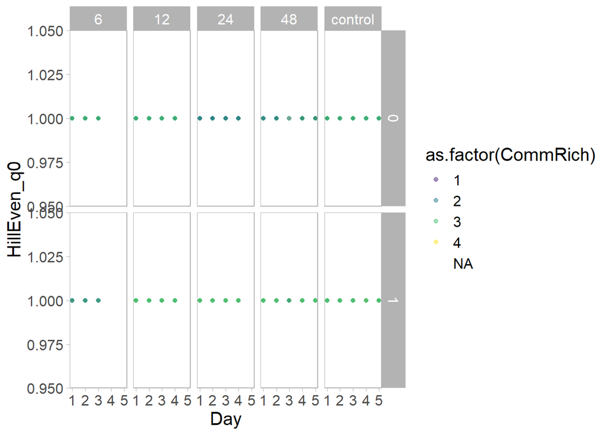

```r
species_div.df <- absDen_forFit %>% mutate(relden_putida = Conc_putida/Total_density,
                                 relden_protegens = Conc_protegens/Total_density,
                                 relden_grimontii = Conc_grimontii/Total_density,
                                 relden_veronii = Conc_veronii/Total_density)
species_div.df <- species_div.df %>% mutate(HillEven_q0 = unlist(calcDiv(sampleData = species_div.df[,c("relden_putida","relden_protegens","relden_grimontii","relden_veronii")],
        type = "HillEven",
        q=0)),
                              HillEven_q1 = unlist(calcDiv(sampleData = species_div.df[,c("relden_putida","relden_protegens","relden_grimontii","relden_veronii")],
        type = "HillEven",
        q=1)),
        HillEven_q2 = unlist(calcDiv(sampleData = species_div.df[,c("relden_putida","relden_protegens","relden_grimontii","relden_veronii")],
        type = "HillEven",
        q=2)),
        HillDiv_q1 = unlist(calcDiv(sampleData = species_div.df[,c("relden_putida","relden_protegens","relden_grimontii","relden_veronii")],
        type = "HillDiv",
        q=1)),
        HillDiv_q2 = unlist(calcDiv(sampleData = species_div.df[,c("relden_putida","relden_protegens","relden_grimontii","relden_veronii")],
        type = "HillDiv",
        q=2)))

ggplot(species_div.df,
       aes(y=HillEven_q0, x=Day, colour=as.factor(CommRich))) +
  facet_grid(protegens~as.factor(Heat)) +
  geom_point(alpha=0.5) +
  scale_colour_viridis_d(option = "viridis", begin=0.1)
```

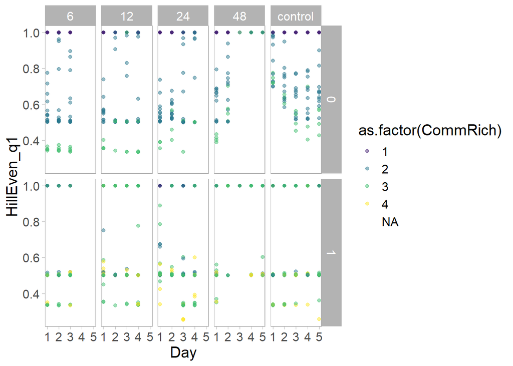

```r
ggplot(species_div.df,
       aes(y=HillEven_q1, x=Day, colour=as.factor(CommRich))) +
  facet_grid(protegens~as.factor(Heat)) +
  geom_point(alpha=0.5) +
  scale_colour_viridis_d(option = "viridis", begin=0.1)
```

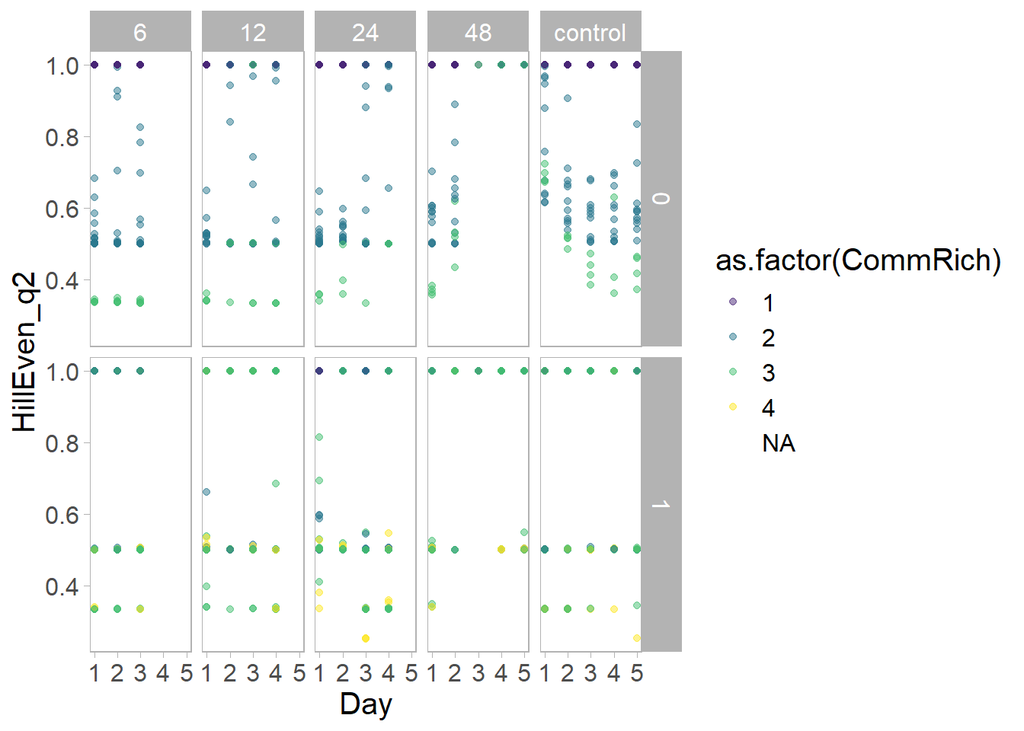

```r
ggplot(species_div.df,
       aes(y=HillEven_q2, x=Day, colour=as.factor(CommRich))) +
  facet_grid(protegens~as.factor(Heat)) +
  geom_point(alpha=0.5) +
  scale_colour_viridis_d(option = "viridis", begin=0.1)
```

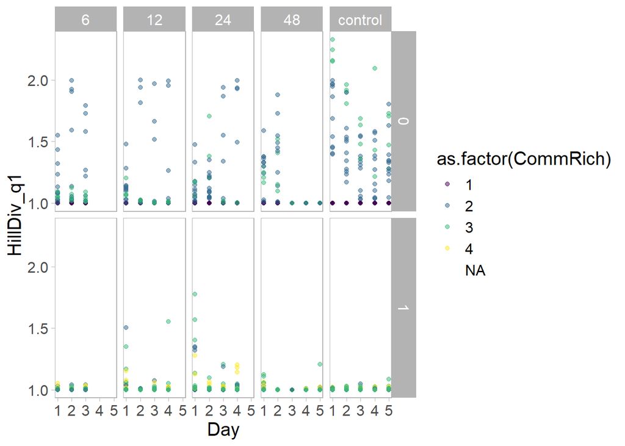

```r
ggplot(species_div.df,
       aes(y=HillDiv_q1, x=Day, colour=as.factor(CommRich))) +
  facet_grid(protegens~as.factor(Heat)) +
  geom_point(alpha=0.5) +
  scale_colour_viridis_d(option = "viridis")
```

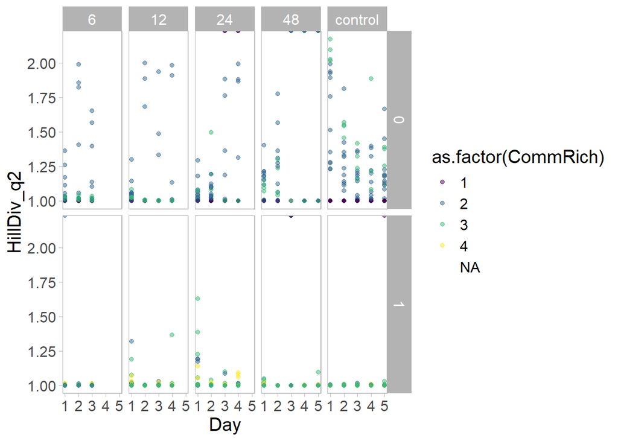

```r
ggplot(species_div.df,
       aes(y=HillDiv_q2, x=Day, colour=as.factor(CommRich))) +
  facet_grid(protegens~as.factor(Heat)) +
  geom_point(alpha=0.5) +
  scale_colour_viridis_d(option = "viridis")
```

```r
# this one gives infinite values. That's not useful.


################################
# Plot figure for main text: Figure 3b
################################

# The Hill Diversity with q=1 seems useful!! Let's include this plot in the final manuscript:
# re-order  the levels of heat so that the control appears first
species_div.df$Heat <- factor(species_div.df$Heat,
                              levels = levels(species_div.df$Heat)[c(5,1:4)])
# change variable names for nicer plotting
levels(species_div.df$Heat)[2:5] <- paste(levels(species_div.df$Heat)[2:5], "hrs")
species_div.df$Pprot_facet <- ifelse(species_div.df$protegens == 0, "P. protegens absent", "P. protegens present")

# create a data.frame for plotting red rectangles in the background
bckgrd <- data.frame(Heat=levels(species_div.df$Heat),
                     HillDiv_q1 = c(0, rep(2.4, 4)),
                     Day = c(0, rep(0.8, 4))) # all heat treatments start at the same time
test <- rbind(bckgrd,
              data.frame(Heat=levels(species_div.df$Heat),
                         HillDiv_q1 = c(0, rep(2.4, 4)),
                         Day = c(0, 1.1, 1.5, 1.9, 2.9))) # choose end points that look good even if not perfectly accurate

png(filename = "./figures/Fig3_B.png", width = 6.98, height = 4.52, units = "in", res = 300)

ggplot(species_div.df %>% filter(CommRich > 1),
        # exclude monocultures bc richness is not informative for these: their richness will always be equal to 1 even when they go extinct.
       aes(y=HillDiv_q1, x=Day)) +
  facet_grid(Pprot_facet ~ as.factor(Heat),
             scales = "free_x", # allow x-axis of facets to freely choose their own max values
             space = "free_x") + # allow facet columns to differ in their sizes
  # add red rectangles in the background to indicate heat treatment as in Fig 1.
  geom_ribbon(data=test, aes(ymin=0.95, ymax=2.4), # add a bit of padding above & below the points to look nice
              position = "identity", # not sure this is needed now that I've switched away from geom_area? But it works so I don't care
              fill="#C43131", alpha=0.25) + # use same colour and alpha as in fill for Fig. 1
  # use beeswarm to jitter the points properly (alpha must be set to 0 bc of red rectangles)
  geom_quasirandom(aes(fill=as.factor(CommRich)), # fill as a function of CommRich *must* be inside of this function otherwise it leads to a lot of problems with the geom_ribbon layer
                   pch=21) + # use points with fill and border bc they look nicer here
  scale_fill_viridis_d(option = "viridis", begin=0.85, end=0) +
  scale_x_continuous(breaks=1:5, # tick marks & tick labels only at integers
                     limits=c(0.5,NA), # add a little extra padding on the left side of x-axis bc I think it looks better
                     expand = c(0, 0.2)) + # for some reason this prevents points in the 6h facet from getting squished up against the right border of the facet
  scale_y_continuous(expand = c(0, 0)) + # this prevents ggplot from adding any extra padding in the y-axis; we already added the defauly +/- 0.05 padding manually when we specified geom_ribbon
  labs(y = "Observed Richness", # 1st order Hill Diversity
       fill = "Inoculated\nRichness") +
  guides(fill = guide_legend(override.aes = list(size=3), # make the points bigger in the legend
                             title.hjust = 0.5)) + # justify the 2nd line of legend title & points so they sit nicely under the 1st line
  theme(strip.background = element_rect(fill = "white", colour="black"),
        strip.text = element_text(color = "black"),
        legend.box.spacing = margin(0.5), # stretch plot rightwards & closer to its legend
        legend.title = element_text(size=14)) # make legend title a little smaller
dev.off()
```

```r
# clean up
rm(species_div.df, bckgrd, test)
```

Notice that for the control condition in the absence of protegens, there is a trend of decreasing species richness over time (e.g., as the communities reach equilibrium).

( ## Analysis?? )

I have effect sizes on richness for resistance and recovery but I’m not sure if this is going to make it into the manuscript… (see the `analyze_temp_serial_transfer_expt--28Oct24.html` if you’re interested).

# Extinction

Which communities were most likely to go extinct? How long did the heat duration have to be in order to drive those communities to extinction?

The simplest hypothesis is that heat duration alone explains whether a community happens to go extinct.

A slightly more complex hypothesis from the thermal performance curve data (Fig. 2) would be that any species that is resistant to heat should be less likely to go extinct, even long duration heat. Therefore we would expect that the presence/absence of the heat resistant species, P. putida, should explain whether a community goes extinct.

Maddy’s hypothesis in setting up this experiment was that a higher inoculated species richness would make a community more resistant to heat. So we are going to check whether the inoculated species richness has any effect.

Another hypothesis that emerges from looking at the time series data itself (e.g., the ordination data) is that protegens has a unique effect on all communities where it is present. So let’s check that model as well.

## Analysis

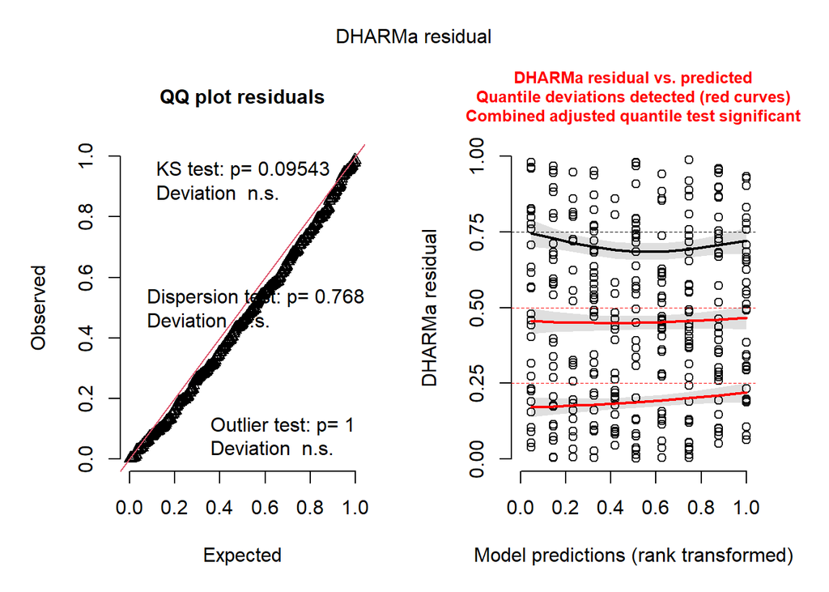

```
## Object of Class DHARMa with simulated residuals based on 250 simulations with refit = FALSE . See ?DHARMa::simulateResiduals for help.
##
## Scaled residual values: 0.9645332 0.959227 0.02965619 0.2301006 0.1030454 0.9776571 0.827906 0.3086776 0.4034651 0.7309843 0.8247881 0.9087348 0.7163956 0.5443066 0.7949462 0.4422744 0.08401695 0.5889396 0.5640054 0.7787241 ...
```

```r
# keep just the data on the last day of each time series
extinct.df <- absDensity %>% filter(Recov_Day == 2)
extinct.df <- rbind(extinct.df,
                    absDensity %>% filter(Heat == 0, Day == 5))
# binary vector of survival or extinction
extinct.df <- extinct.df %>% mutate(survived = ifelse(Total_density > 0, 1, 0))
### note that sample "24-07-08 Epoch G1" has missing data on Day 5 even though we know from the OD data that it survived.
extinct.df$survived[extinct.df$uniqID == "24-07-08 Epoch G1"] <- 1

# make protegens into a factor
extinct.df$protegens <- factor(extinct.df$protegens)

# fit the models
ext_mod.heat <- glmmTMB(survived ~ Heat,
                          data = extinct.df,
                          family = binomial,
                          control = glmmTMBControl(optCtrl = list(iter.max = 500000,eval.max = 500000)))
#simulateResiduals(fittedModel = ext_mod.heat, plot = TRUE)

ext_mod.heat_plus_rich <- glmmTMB(survived ~ CommRich + Heat,
                          data = extinct.df,
                          family = binomial,
                          control = glmmTMBControl(optCtrl = list(iter.max = 500000,eval.max = 500000)))
#simulateResiduals(fittedModel = ext_mod.heat_plus_rich, plot = TRUE)

ext_mod.heat_plus_prot <- glmmTMB(survived ~ Heat + protegens,
                          data = extinct.df,
                          family = binomial,
                          control = glmmTMBControl(optCtrl = list(iter.max = 500000,eval.max = 500000)))
simulateResiduals(fittedModel = ext_mod.heat_plus_prot, plot = TRUE)
```

```r
ext_mod.heat_plus_resist <- glmmTMB(survived ~ Heat + resistant,
                          data = extinct.df,
                          family = binomial,
                          control = glmmTMBControl(optCtrl = list(iter.max = 500000,eval.max = 500000)))
#simulateResiduals(fittedModel = ext_mod.heat_plus_resist, plot = TRUE)


ext_mod.heat_by_rich <- glmmTMB(survived ~ CommRich*Heat,
                          data = extinct.df,
                          family = binomial,
                          control = glmmTMBControl(optCtrl = list(iter.max = 500000,eval.max = 500000)))
#simulateResiduals(fittedModel = ext_mod.heat_by_rich, plot = TRUE)

ext_mod.heat_by_prot <- glmmTMB(survived ~ Heat*protegens,
                          data = extinct.df,
                          family = binomial,
                          control = glmmTMBControl(optCtrl = list(iter.max = 500000,eval.max = 500000)))
#simulateResiduals(fittedModel = ext_mod.heat_by_prot, plot = TRUE)


ext_mod.heat_rich_prot <- glmmTMB(survived ~ CommRich + Heat + protegens,
                          data = extinct.df,
                          family = binomial,
                          control = glmmTMBControl(optCtrl = list(iter.max = 500000,eval.max = 500000)))
#simulateResiduals(fittedModel = ext_mod.heat_rich_prot, plot = TRUE)

ext_mod.rich_heatXprot <- glmmTMB(survived ~ CommRich + Heat*protegens,
                          data = extinct.df,
                          family = binomial,
                          control = glmmTMBControl(optCtrl = list(iter.max = 500000,eval.max = 500000)))
#simulateResiduals(fittedModel = ext_mod.rich_heatXprot, plot = TRUE)

#anova(ext_mod.heat, ext_mod.heat_plus_rich)
#anova(ext_mod.heat, ext_mod.heat_by_rich)
#anova(ext_mod.heat_plus_rich, ext_mod.heat_by_rich)

AIC(ext_mod.heat, ext_mod.heat_plus_rich, ext_mod.heat_plus_prot, ext_mod.heat_by_rich, ext_mod.heat_by_prot, ext_mod.heat_rich_prot, ext_mod.rich_heatXprot, ext_mod.heat_plus_resist) %>% arrange(AIC)
```

|  | df | AIC |
| --- | --- | --- |
| ext_mod.heat_plus_prot | 3 | 61.11501 |
| ext_mod.heat_rich_prot | 4 | 62.06639 |
| ext_mod.rich_heatXprot | 5 | 64.06639 |
| ext_mod.heat_plus_rich | 3 | 89.63300 |
| ext_mod.heat_by_rich | 4 | 89.77641 |
| ext_mod.heat_plus_resist | 3 | 93.95280 |
| ext_mod.heat | 2 | 97.39355 |
| ext_mod.heat_by_prot | 4 | NA |

```r
AICc(ext_mod.heat, ext_mod.heat_plus_rich, ext_mod.heat_plus_prot, ext_mod.heat_by_rich, ext_mod.heat_by_prot, ext_mod.heat_rich_prot, ext_mod.rich_heatXprot, ext_mod.heat_plus_resist) %>% arrange(AICc)
```

|  | df | AICc |
| --- | --- | --- |
| ext_mod.heat_plus_prot | 3 | 61.19001 |
| ext_mod.heat_rich_prot | 4 | 62.19178 |
| ext_mod.rich_heatXprot | 5 | 64.25507 |
| ext_mod.heat_plus_rich | 3 | 89.70800 |
| ext_mod.heat_by_rich | 4 | 89.90180 |
| ext_mod.heat_plus_resist | 3 | 94.02780 |
| ext_mod.heat | 2 | 97.43093 |
| ext_mod.heat_by_prot | 4 | NA |

```r
BIC(ext_mod.heat, ext_mod.heat_plus_rich, ext_mod.heat_plus_prot, ext_mod.heat_by_rich, ext_mod.heat_by_prot, ext_mod.heat_rich_prot, ext_mod.rich_heatXprot, ext_mod.heat_plus_resist) %>% arrange(BIC)
```

|  | df | BIC |
| --- | --- | --- |
| ext_mod.heat_plus_prot | 3 | 72.45724 |
| ext_mod.heat_rich_prot | 4 | 77.18936 |
| ext_mod.rich_heatXprot | 5 | 82.97011 |
| ext_mod.heat_plus_rich | 3 | 100.97523 |
| ext_mod.heat_by_rich | 4 | 104.89939 |
| ext_mod.heat | 2 | 104.95504 |
| ext_mod.heat_plus_resist | 3 | 105.29503 |
| ext_mod.heat_by_prot | 4 | NA |

```r
summary(ext_mod.heat_rich_prot)
```

```
##  Family: binomial  ( logit )
## Formula:          survived ~ CommRich + Heat + protegens
## Data: extinct.df
##
##       AIC       BIC    logLik -2*log(L)  df.resid
##      62.1      77.2     -27.0      54.1       320
##
##
## Conditional model:
##               Estimate Std. Error z value Pr(>|z|)
## (Intercept)  5.688e+00  1.512e+00   3.763 0.000168 ***
## CommRich     5.080e-01  5.035e-01   1.009 0.312982
## Heat        -1.445e-01  3.096e-02  -4.666 3.07e-06 ***
## protegens1   2.305e+01  1.592e+04   0.001 0.998844
## ---
## Signif. codes:  0 '***' 0.001 '**' 0.01 '*' 0.05 '.' 0.1 ' ' 1
```

```r
summary(ext_mod.heat_plus_prot)
```

```
##  Family: binomial  ( logit )
## Formula:          survived ~ Heat + protegens
## Data: extinct.df
##
##       AIC       BIC    logLik -2*log(L)  df.resid
##      61.1      72.5     -27.6      55.1       321
##
##
## Conditional model:
##               Estimate Std. Error z value Pr(>|z|)
## (Intercept)  6.459e+00  1.340e+00   4.820 1.43e-06 ***
## Heat        -1.425e-01  3.038e-02  -4.690 2.73e-06 ***
## protegens1   2.363e+01  1.849e+04   0.001    0.999
## ---
## Signif. codes:  0 '***' 0.001 '**' 0.01 '*' 0.05 '.' 0.1 ' ' 1
```

```r
anova(ext_mod.heat, ext_mod.heat_plus_prot)
```

|  | Df | AIC | BIC | logLik | deviance | Chisq | Chi Df | Pr(>Chisq) |
| --- | --- | --- | --- | --- | --- | --- | --- | --- |
| ext_mod.heat | 2 | 97.39355 | 104.95504 | -46.69677 | 93.39355 | NA | NA | NA |
| ext_mod.heat_plus_prot | 3 | 61.11501 | 72.45724 | -27.55751 | 55.11501 | 38.27854 | 1 | 6.133354e-10 |

```r
anova(ext_mod.heat_plus_prot, ext_mod.heat_rich_prot)
```

|  | Df | AIC | BIC | logLik | deviance | Chisq | Chi Df | Pr(>Chisq) |
| --- | --- | --- | --- | --- | --- | --- | --- | --- |
| ext_mod.heat_plus_prot | 3 | 61.11501 | 72.45724 | -27.55751 | 55.11501 | NA | NA | NA |
| ext_mod.heat_rich_prot | 4 | 62.06639 | 77.18936 | -27.03319 | 54.06639 | 1.048622 | 1 | 0.3058246 |

```r
# and let's report the R-squared for this
efronRSquared(residual = residuals(ext_mod.heat_plus_prot, type="response"),
              predicted = predict(ext_mod.heat_plus_prot, type="response"),
              statistic = "EfronRSquared")
```

```
## EfronRSquared
##         0.501
```

This tells us that the most important predictors are: 1. the duration of the heat event and 2. the presence/absence of protegens in the inoculated community. This model explains about 50% of the variation in the data. We have little power to detect an effect of inoculated community richness on the extinction.

A final possibility is that the growth rates of the different communities can explain whether they go extinct. Let’s check if the average growth rate of the community at 30C can predict its extinction…

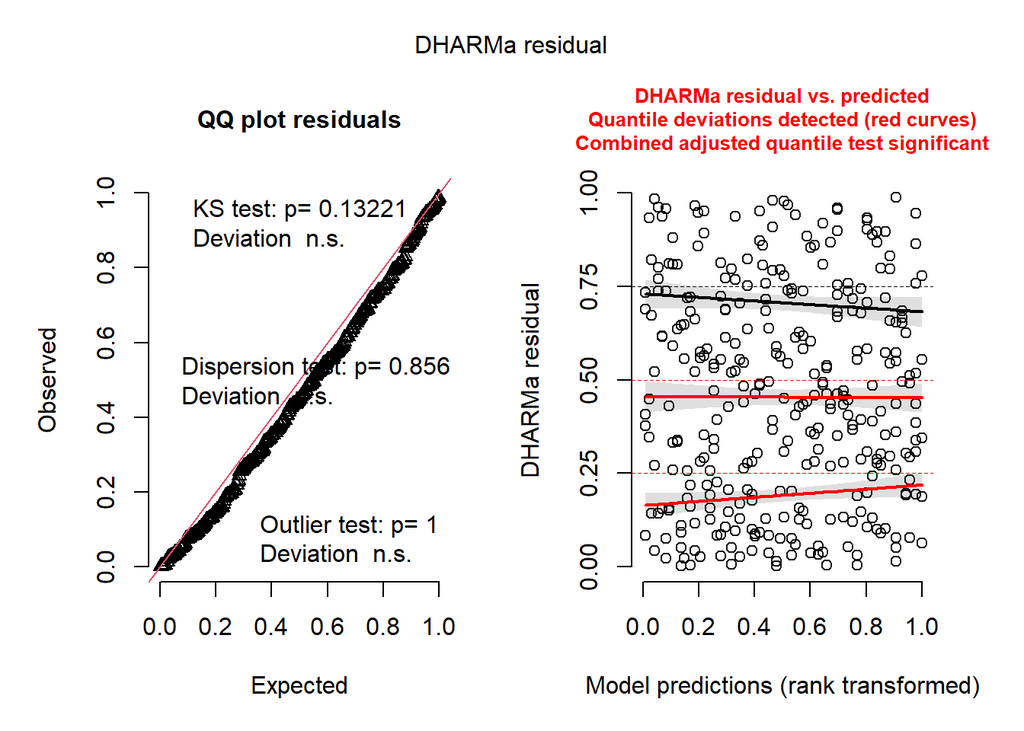

```
## Object of Class DHARMa with simulated residuals based on 250 simulations with refit = FALSE . See ?DHARMa::simulateResiduals for help.
##
## Scaled residual values: 0.9628912 0.9384698 0.02965619 0.4072284 0.1428897 0.9776571 0.6471349 0.3086776 0.6884299 0.7309843 0.8014265 0.9087348 0.7163956 0.5443066 0.7949462 0.5218201 0.08401695 0.5889396 0.05015453 0.7787241 ...
```

```r
ext_mod.expect_mu <- glmmTMB(survived ~ Heat + community_expected_mu,
                          data = extinct.df,
                          family = binomial,
                          control = glmmTMBControl(optCtrl = list(iter.max = 500000,eval.max = 500000)))
#simulateResiduals(fittedModel = ext_mod.expect_mu, plot = TRUE)

ext_mod.exptmu_prot <- glmmTMB(survived ~ Heat + community_expected_mu + protegens,
                          data = extinct.df,
                          family = binomial,
                          control = glmmTMBControl(optCtrl = list(iter.max = 500000,eval.max = 500000)))
simulateResiduals(fittedModel = ext_mod.exptmu_prot, plot = TRUE)
```

```r
ext_mod.exptmuXprot <- glmmTMB(survived ~ Heat + community_expected_mu*protegens,
                          data = extinct.df,
                          family = binomial,
                          control = glmmTMBControl(optCtrl = list(iter.max = 500000,eval.max = 500000)))
simulateResiduals(fittedModel = ext_mod.exptmu_prot, plot = TRUE)
```

```
## Object of Class DHARMa with simulated residuals based on 250 simulations with refit = FALSE . See ?DHARMa::simulateResiduals for help.
##
## Scaled residual values: 0.9628912 0.9384698 0.02965619 0.4072284 0.1428897 0.9776571 0.6471349 0.3086776 0.6884299 0.7309843 0.8014265 0.9087348 0.7163956 0.5443066 0.7949462 0.5218201 0.08401695 0.5889396 0.05015453 0.7787241 ...
```

```r
ext_mod.heatXexptmu_prot <- glmmTMB(survived ~ Heat*community_expected_mu + protegens,
                          data = extinct.df,
                          family = binomial,
                          control = glmmTMBControl(optCtrl = list(iter.max = 500000,eval.max = 500000)))
simulateResiduals(fittedModel = ext_mod.exptmu_prot, plot = TRUE)
```

```
## Object of Class DHARMa with simulated residuals based on 250 simulations with refit = FALSE . See ?DHARMa::simulateResiduals for help.
##
## Scaled residual values: 0.9628912 0.9384698 0.02965619 0.4072284 0.1428897 0.9776571 0.6471349 0.3086776 0.6884299 0.7309843 0.8014265 0.9087348 0.7163956 0.5443066 0.7949462 0.5218201 0.08401695 0.5889396 0.05015453 0.7787241 ...
```

```r
ext_mod.heatXprot_exptmu <- glmmTMB(survived ~ Heat*protegens + community_expected_mu,
                          data = extinct.df,
                          family = binomial,
                          control = glmmTMBControl(optCtrl = list(iter.max = 500000,eval.max = 500000)))
simulateResiduals(fittedModel = ext_mod.exptmu_prot, plot = TRUE)
```

```
## Object of Class DHARMa with simulated residuals based on 250 simulations with refit = FALSE . See ?DHARMa::simulateResiduals for help.
##
## Scaled residual values: 0.9628912 0.9384698 0.02965619 0.4072284 0.1428897 0.9776571 0.6471349 0.3086776 0.6884299 0.7309843 0.8014265 0.9087348 0.7163956 0.5443066 0.7949462 0.5218201 0.08401695 0.5889396 0.05015453 0.7787241 ...
```

```r
ext_mod.heatXprotXexptmu <- glmmTMB(survived ~ Heat*protegens*community_expected_mu,
                          data = extinct.df,
                          family = binomial,
                          control = glmmTMBControl(optCtrl = list(iter.max = 500000,eval.max = 500000)))
simulateResiduals(fittedModel = ext_mod.exptmu_prot, plot = TRUE)
```

```
## Object of Class DHARMa with simulated residuals based on 250 simulations with refit = FALSE . See ?DHARMa::simulateResiduals for help.
##
## Scaled residual values: 0.9628912 0.9384698 0.02965619 0.4072284 0.1428897 0.9776571 0.6471349 0.3086776 0.6884299 0.7309843 0.8014265 0.9087348 0.7163956 0.5443066 0.7949462 0.5218201 0.08401695 0.5889396 0.05015453 0.7787241 ...
```

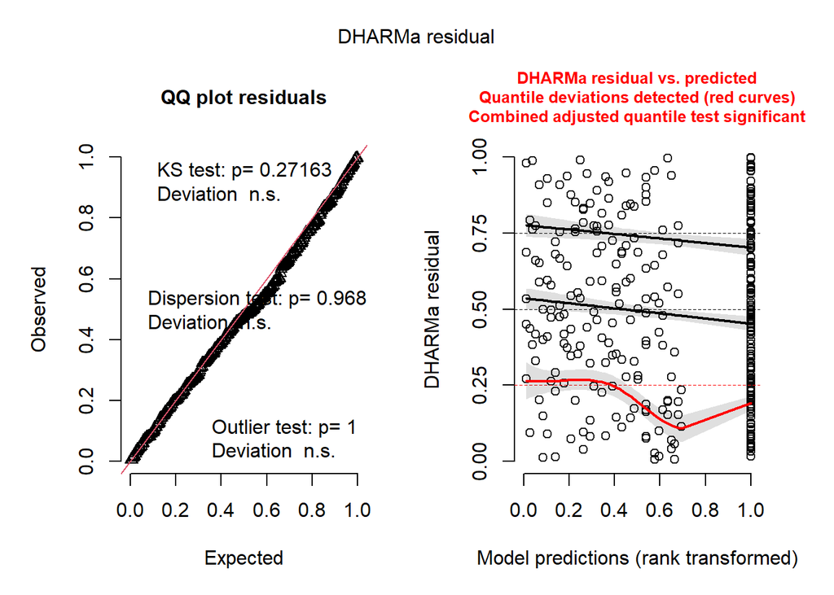

```
## Object of Class DHARMa with simulated residuals based on 250 simulations with refit = FALSE . See ?DHARMa::simulateResiduals for help.
##
## Scaled residual values: 0.4089731 0.6516057 0.5394315 0.4501793 0.9890527 0.5333557 0.2309646 0.3948581 0.6868779 0.02586429 0.5943815 0.08103522 0.8765983 0.7344452 0.2819697 0.6605734 0.1427851 0.5192184 0.291833 0.4861997 ...
```

```r
ext_mod.averaged_mu <- glmmTMB(survived ~ Heat + community_averaged_mu,
                          data = extinct.df,
                          family = binomial,
                          control = glmmTMBControl(optCtrl = list(iter.max = 500000,eval.max = 500000)))
#simulateResiduals(fittedModel = ext_mod.averaged_mu, plot = TRUE)

ext_mod.avemu_prot <- glmmTMB(survived ~ Heat + community_averaged_mu + protegens,
                          data = extinct.df,
                          family = binomial,
                          control = glmmTMBControl(optCtrl = list(iter.max = 500000,eval.max = 500000)))
simulateResiduals(fittedModel = ext_mod.avemu_prot, plot = TRUE)
```

```r
ext_mod.exptmu_prot_resist <- glmmTMB(survived ~ Heat + community_expected_mu + protegens + resistant,
                          data = extinct.df,
                          family = binomial,
                          control = glmmTMBControl(optCtrl = list(iter.max = 500000,eval.max = 500000)))
#simulateResiduals(fittedModel = ext_mod.exptmu_prot_resist, plot = TRUE)

summary(ext_mod.exptmu_prot)
```

```
##  Family: binomial  ( logit )
## Formula:          survived ~ Heat + community_expected_mu + protegens
## Data: extinct.df
##
##       AIC       BIC    logLik -2*log(L)  df.resid
##      42.1      57.2     -17.0      34.1       320
##
##
## Conditional model:
##                         Estimate Std. Error z value Pr(>|z|)
## (Intercept)           -3.080e+00  3.035e+00  -1.015  0.31019
## Heat                  -2.152e-01  5.309e-02  -4.054 5.03e-05 ***
## community_expected_mu  1.463e+01  5.024e+00   2.912  0.00359 **
## protegens1             2.433e+01  2.154e+04   0.001  0.99910
## ---
## Signif. codes:  0 '***' 0.001 '**' 0.01 '*' 0.05 '.' 0.1 ' ' 1
```

```r
summary(ext_mod.avemu_prot)
```

```
##  Family: binomial  ( logit )
## Formula:          survived ~ Heat + community_averaged_mu + protegens
## Data: extinct.df
##
##       AIC       BIC    logLik -2*log(L)  df.resid
##      35.8      51.0     -13.9      27.8       320
##
##
## Conditional model:
##                         Estimate Std. Error z value Pr(>|z|)
## (Intercept)              -3.2158     2.9907  -1.075   0.2823
## Heat                     -0.5403     0.2515  -2.149   0.0317 *
## community_averaged_mu    26.8226    12.9368   2.073   0.0381 *
## protegens1               27.7150 24864.3060   0.001   0.9991
## ---
## Signif. codes:  0 '***' 0.001 '**' 0.01 '*' 0.05 '.' 0.1 ' ' 1
```

```r
# this model does not converge bc of the experimental design (some predictor combinations are unitary)
summary(ext_mod.exptmu_prot_resist)
```

```
##  Family: binomial  ( logit )
## Formula:
## survived ~ Heat + community_expected_mu + protegens + resistant
## Data: extinct.df
##
##       AIC       BIC    logLik -2*log(L)  df.resid
##        NA        NA        NA        NA       319
##
##
## Conditional model:
##                       Estimate Std. Error z value Pr(>|z|)
## (Intercept)             36.833        NaN     NaN      NaN
## Heat                    -1.711        NaN     NaN      NaN
## community_expected_mu    8.399        NaN     NaN      NaN
## protegens1              79.339        NaN     NaN      NaN
## resistant               37.915        NaN     NaN      NaN
```

```r
## this should go in a single table instead of 3 diferent ones:
AIC(ext_mod.heat, ext_mod.heat_plus_prot, ext_mod.rich_heatXprot, ext_mod.heat_plus_resist, ext_mod.expect_mu, ext_mod.averaged_mu, ext_mod.exptmu_prot, ext_mod.avemu_prot, ext_mod.exptmu_prot_resist, ext_mod.exptmuXprot, ext_mod.heatXexptmu_prot, ext_mod.heatXprot_exptmu, ext_mod.heatXprotXexptmu) %>% arrange(AIC)
```

|  | df | AIC |
| --- | --- | --- |
| ext_mod.avemu_prot | 4 | 35.83109 |
| ext_mod.exptmu_prot | 4 | 42.07826 |
| ext_mod.exptmuXprot | 5 | 44.07826 |
| ext_mod.heat_plus_prot | 3 | 61.11501 |
| ext_mod.rich_heatXprot | 5 | 64.06639 |
| ext_mod.expect_mu | 3 | 72.60455 |
| ext_mod.averaged_mu | 3 | 75.99506 |
| ext_mod.heat_plus_resist | 3 | 93.95280 |
| ext_mod.heat | 2 | 97.39355 |
| ext_mod.exptmu_prot_resist | 5 | NA |

[output cut: 3 more lines]

```r
AICc(ext_mod.heat, ext_mod.heat_plus_prot, ext_mod.rich_heatXprot, ext_mod.heat_plus_resist, ext_mod.expect_mu, ext_mod.averaged_mu, ext_mod.exptmu_prot, ext_mod.avemu_prot, ext_mod.exptmu_prot_resist, ext_mod.exptmuXprot, ext_mod.heatXexptmu_prot, ext_mod.heatXprot_exptmu, ext_mod.heatXprotXexptmu) %>% arrange(AICc)
```

|  | df | AICc |
| --- | --- | --- |
| ext_mod.avemu_prot | 4 | 35.95648 |
| ext_mod.exptmu_prot | 4 | 42.20365 |
| ext_mod.exptmuXprot | 5 | 44.26694 |
| ext_mod.heat_plus_prot | 3 | 61.19001 |
| ext_mod.rich_heatXprot | 5 | 64.25507 |
| ext_mod.expect_mu | 3 | 72.67955 |
| ext_mod.averaged_mu | 3 | 76.07006 |
| ext_mod.heat_plus_resist | 3 | 94.02780 |
| ext_mod.heat | 2 | 97.43093 |
| ext_mod.exptmu_prot_resist | 5 | NA |

[output cut: 3 more lines]

```r
BIC(ext_mod.heat, ext_mod.heat_plus_prot, ext_mod.rich_heatXprot, ext_mod.heat_plus_resist, ext_mod.expect_mu, ext_mod.averaged_mu, ext_mod.exptmu_prot, ext_mod.avemu_prot, ext_mod.exptmu_prot_resist, ext_mod.exptmuXprot, ext_mod.heatXexptmu_prot, ext_mod.heatXprot_exptmu, ext_mod.heatXprotXexptmu) %>% arrange(BIC)
```

|  | df | BIC |
| --- | --- | --- |
| ext_mod.avemu_prot | 4 | 50.95406 |
| ext_mod.exptmu_prot | 4 | 57.20123 |
| ext_mod.exptmuXprot | 5 | 62.98197 |
| ext_mod.heat_plus_prot | 3 | 72.45724 |
| ext_mod.rich_heatXprot | 5 | 82.97011 |
| ext_mod.expect_mu | 3 | 83.94678 |
| ext_mod.averaged_mu | 3 | 87.33729 |
| ext_mod.heat | 2 | 104.95504 |
| ext_mod.heat_plus_resist | 3 | 105.29503 |
| ext_mod.exptmu_prot_resist | 5 | NA |

[output cut: 3 more lines]

```r
# wow, I'm shocked that this growth rate model is actually better. Let's double check that...
anova(ext_mod.heat_plus_prot, ext_mod.exptmu_prot)
```

|  | Df | AIC | BIC | logLik | deviance | Chisq | Chi Df | Pr(>Chisq) |
| --- | --- | --- | --- | --- | --- | --- | --- | --- |
| ext_mod.heat_plus_prot | 3 | 61.11501 | 72.45724 | -27.55751 | 55.11501 | NA | NA | NA |
| ext_mod.exptmu_prot | 4 | 42.07826 | 57.20123 | -17.03913 | 34.07826 | 21.03675 | 1 | 4.505567e-06 |

```r
anova(ext_mod.heat_plus_prot, ext_mod.avemu_prot)
```

|  | Df | AIC | BIC | logLik | deviance | Chisq | Chi Df | Pr(>Chisq) |
| --- | --- | --- | --- | --- | --- | --- | --- | --- |
| ext_mod.heat_plus_prot | 3 | 61.11501 | 72.45724 | -27.55751 | 55.11501 | NA | NA | NA |
| ext_mod.avemu_prot | 4 | 35.83109 | 50.95406 | -13.91554 | 27.83109 | 27.28392 | 1 | 1.75666e-07 |

```r
# let's check if the expected_mu model with interactions is able to get a better estimate on the effect of protegens:
summary(ext_mod.exptmuXprot) # no, it's the same
```

```
##  Family: binomial  ( logit )
## Formula:          survived ~ Heat + community_expected_mu * protegens
## Data: extinct.df
##
##       AIC       BIC    logLik -2*log(L)  df.resid
##      44.1      63.0     -17.0      34.1       319
##
##
## Conditional model:
##                                    Estimate Std. Error z value Pr(>|z|)
## (Intercept)                      -3.080e+00  3.035e+00  -1.015  0.31019
## Heat                             -2.152e-01  5.309e-02  -4.054 5.03e-05 ***
## community_expected_mu             1.463e+01  5.024e+00   2.912  0.00359 **
## protegens1                        1.917e+01  4.099e+05   0.000  0.99996
## community_expected_mu:protegens1  6.392e+00  5.051e+05   0.000  0.99999
## ---
## Signif. codes:  0 '***' 0.001 '**' 0.01 '*' 0.05 '.' 0.1 ' ' 1
```

```r
# get the 95% confidence intervals:
print("expected mu:")
```

```
## [1] "expected mu:"
```

```r
confint(ext_mod.exptmu_prot)
```

```
##                               2.5 %        97.5 %   Estimate
## (Intercept)               -9.028488     2.8685403 -3.0799739
## Heat                      -0.319264    -0.1111684 -0.2152162
## community_expected_mu      4.784301    24.4766683 14.6304845
## protegens1            -42192.404379 42241.0685341 24.3320775
```

```r
print("realized average mu:")
```

```
## [1] "realized average mu:"
```

```r
confint(ext_mod.avemu_prot)
```

```
##                               2.5 %        97.5 %   Estimate
## (Intercept)               -9.077401  2.645851e+00 -3.2157748
## Heat                      -1.033214 -4.744673e-02 -0.5403302
## community_averaged_mu      1.466930  5.217824e+01 26.8225864
## protegens1            -48705.429291  4.876086e+04 27.7149920
```

```r
# and let's report the R-squared
efronRSquared(residual = residuals(ext_mod.exptmu_prot, type="response"),
              predicted = predict(ext_mod.exptmu_prot, type="response"),
              statistic = "EfronRSquared")
```

```
## EfronRSquared
##         0.707
```

```r
efronRSquared(residual = residuals(ext_mod.avemu_prot, type="response"),
              predicted = predict(ext_mod.avemu_prot, type="response"),
              statistic = "EfronRSquared")
```

```
## EfronRSquared
##         0.747
```

Ok, so neither the community_expected_mu nor the community_averaged_mu are as good predictors as just heat duration and presence/absence of protegens. But when we add the presence/absence of protegens to either the community_expected_mu or community_averaged_mu, we get very good models that are significantly better than the one reported above. e.g., The model with just heat duration and protegens presence/absence explains 50% of the variation, while models explain 70-75% of the variation. Another way to report this result is to give the $\Delta$AIC or $\Delta$BIC.

Most of the models with community_expected_mu and interactions failed to converge. The one that succeeded is about the same as the simpler, additive model ($\Delta$AIC = 2) but it’s definitely less preferred by BIC than the simpler additive model ($\Delta$BIC = 5.78). In addition, there is absolutely no improvement in the estimate for protegens in this interactions model (and the interaction itself cannot be reliably estimated either).

Although the community_averaged_mu is a better fit, I prefer to use the community_expected_mu because it fits better in the framework of “can we predict microbial community dynamics from the species traits?” Moreover, the fit (at least for the extinction data) is not that much worse for the community_expected_mu as compared to the community_averaged_mu – and both are insufficient to explain the data without the effect of protegens anyway!

```r
absDensity <- absDensity %>% select(-community_averaged_mu)
absDen_forFit <- absDen_forFit %>% select(-community_averaged_mu)
extinct.df <- extinct.df %>% select(-community_averaged_mu)
```

## Odds ratios

For easier interpretation of the logistic regression effect sizes, let’s get the odds ratios of extinction. (Note that above we were getting the odds ratios of *survival*).

```r
best_model <- glmmTMB((1-survived) ~ Heat + community_expected_mu + protegens,
                          data = extinct.df,
                          family = binomial,
                          control = glmmTMBControl(optCtrl = list(iter.max = 500000,eval.max = 500000)))

# check that this result is consistent with the model we had before
summary(best_model) # it is indeed consistent
```

```
##  Family: binomial  ( logit )
## Formula:          (1 - survived) ~ Heat + community_expected_mu + protegens
## Data: extinct.df
##
##       AIC       BIC    logLik -2*log(L)  df.resid
##      42.1      57.2     -17.0      34.1       320
##
##
## Conditional model:
##                         Estimate Std. Error z value Pr(>|z|)
## (Intercept)            3.080e+00  3.035e+00   1.015  0.31019
## Heat                   2.152e-01  5.309e-02   4.054 5.03e-05 ***
## community_expected_mu -1.463e+01  5.024e+00  -2.912  0.00359 **
## protegens1            -2.433e+01  2.154e+04  -0.001  0.99910
## ---
## Signif. codes:  0 '***' 0.001 '**' 0.01 '*' 0.05 '.' 0.1 ' ' 1
```

```r
# print the odds ratios
exp(confint(best_model))
```

```
##                              2.5 %       97.5 %     Estimate
## (Intercept)           5.678175e-02 8.337244e+03 2.175783e+01
## Heat                  1.117583e+00 1.376115e+00 1.240130e+00
## community_expected_mu 2.343786e-11 8.359968e-03 4.426509e-07
## protegens1            0.000000e+00          Inf 2.708401e-11
```

```r
# get the number of replicates that either did or did not have protegens for each heat treatment:
extinct.df %>% mutate(died = 1-survived) %>%
  group_by(protegens, Heat) %>%
    summarise(total_reps = n(),
              survived = sum(survived),
              extinct = sum(died)) %>%
      as.data.frame()
```

| protegens | Heat | total_reps | survived | extinct |
| --- | --- | --- | --- | --- |
| 0 | 0 | 22 | 22 | 0 |
| 0 | 6 | 34 | 34 | 0 |
| 0 | 12 | 23 | 23 | 0 |
| 0 | 24 | 31 | 29 | 2 |
| 0 | 48 | 29 | 12 | 17 |
| 1 | 0 | 35 | 35 | 0 |
| 1 | 6 | 40 | 40 | 0 |
| 1 | 12 | 40 | 40 | 0 |
| 1 | 24 | 35 | 35 | 0 |
| 1 | 48 | 35 | 35 | 0 |

```r
# do the same but for putida
extinct.df %>% mutate(died = 1-survived) %>%
  group_by(putida, Heat) %>%
    summarise(total_reps = n(),
              survived = sum(survived),
              extinct = sum(died)) %>%
      as.data.frame()
```

| putida | Heat | total_reps | survived | extinct |
| --- | --- | --- | --- | --- |
| 0 | 0 | 26 | 26 | 0 |
| 0 | 6 | 34 | 34 | 0 |
| 0 | 12 | 29 | 29 | 0 |
| 0 | 24 | 31 | 29 | 2 |
| 0 | 48 | 29 | 18 | 11 |
| 1 | 0 | 31 | 31 | 0 |
| 1 | 6 | 40 | 40 | 0 |
| 1 | 12 | 34 | 34 | 0 |
| 1 | 24 | 35 | 35 | 0 |
| 1 | 48 | 35 | 29 | 6 |

```r
rm(best_model)
```

The effect of protegens is large but unreliable. I also report the total number of replicates with protegens at 24h and 48h and with putida at 24h and 48h just to give an idea.